**Roadmap Penelitian S2 Statistika Terapan**FMIPA Universitas Padjadjaran · 2023–2033

[figure not shown]

S2 STATISTIKA TERAPAN · FMIPA UNPAD

# Roadmap Penelitian Program Studi 2023–2033

Roadmap penelitian berbasis evidence yang mengintegrasikan dua payung utama, portofolio riset dosen, penelitian dosen–mahasiswa, publikasi, hibah, kolaborasi, dan target dampak akademik maupun sosial.

◷ Periode 2023–2033 ◆ 2 payung penelitian ▥ 45 hibah/penelitian dosen ↗ Final Agustus 2025

[figure not shown]

**Roadmap Penelitian**Final Agustus 2025

Executive dashboard

## Ringkasan Roadmap

Ringkasan bukti, kapasitas, dan arah pengembangan 2023–2033.

**45**Hibah/penelitian dosen 2022–2026

**Rp2,74 M**Total pendanaan terdokumentasi

**124**Rekam publikasi dosen 2022–2026

**64**Luaran dosen–mahasiswa

**32**Publikasi Scopus Q1 pada dataset dosen

**2**Payung penelitian utama

### Evidence hibah/penelitian per tahun

4

2022

13

2023

7

2024

17

2025

4

2026

### Portofolio publikasi dosen

7

2022

9

2023

22

2024

66

2025

20

2026

Payung I

### Health Statistics & Health Data Science

Biostatistics, epidemiological methods, spatial/spatio-temporal health, Bayesian uncertainty, causal-policy health analytics, dan responsible prediction.

Payung II

### Data Science & Advanced Applied Statistics

Statistical learning, Bayesian data science, spatial data science, survey/official statistics, business-industry-actuarial analytics, dan reproducible computing.

Horizon 10 tahun

## Roadmap Penelitian 2023–2033

Empat fase yang menghubungkan fondasi akademik, konsolidasi portofolio, ekspansi kolaborasi, serta dampak dan rekognisi.

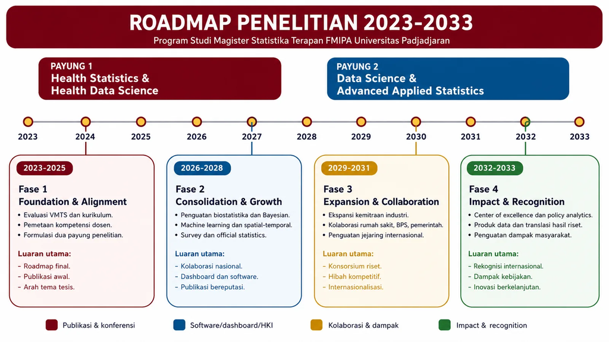

**2023–2025**Foundation & Alignment: evaluasi VMTS, pemetaan kompetensi, formulasi dua payung, validasi dan finalisasi.

**2026–2028**Consolidation & Growth: penguatan klaster, tesis, software/dashboard, publikasi dan kolaborasi nasional.

**2029–2031**Expansion & Collaboration: kemitraan industri, kesehatan, BPS/pemerintah dan jejaring internasional.

**2032–2033**Impact & Recognition: center of excellence, policy analytics, data products, dampak masyarakat dan rekognisi internasional.

### Interpretasi

Roadmap 2023-2033 membagi pengembangan ke dalam empat fase: foundation and alignment, consolidation and growth, expansion and collaboration, serta impact and recognition. Urutan tersebut menunjukkan bahwa rekognisi internasional dan dampak ditempatkan sebagai hasil dari fondasi evidence, penguatan kapasitas, dan kolaborasi yang dibangun secara bertahap.

Traceable evidence

## Bukti penelitian, hibah, dan keterlibatan mahasiswa

Data dapat dicari dan difilter. Rekam 2026 diposisikan sebagai tindak lanjut pasca-pengesahan Agustus 2025.

2026*Q1*

### Mapping and Forecasting District-Level Stunting Dynamics in Indonesia Toward SDG Target 2.2: A Hybrid Bayesian-Machine Learning Spatiotemporal Analysis

**Dr. I Gede Nyoman Mindra Jaya, S.Si., M.Si; Dr. Bertho Tantular, S.Si., M.Si**  
Kiki Amelia · Sustainability

2026*Q1*

### Evaluating the Impact of the Government Floor Price Policy (HPP) on Farm-Gate-Level Harvested Dry Paddy (GKP) Price Trends Through Machine Learning-Based Forecasting

**Dr. Gumgum Darmawan, S.Si., M.Si; Dr. Bertho Tantular, S.Si., M.Si; Dr. Sri Winarni, S.Si., M.Si**  
Fellita Odelia Wibowo · Mathematics

2023*Q2*

### Air Quality Mapping in Bandung City

**Dr. Bertho Tantular, S.Si., M.Si; Prof. Dr. Toni Toharudin, M.Sc**  
Leivina Saliaputri · Atmosphere

2024*Q1*

### Sensitivity analysis of the PC hyperprior for range and standard deviation components in Bayesian Spatiotemporal high-resolution prediction: An application to PM2.5 prediction in Jakarta, Indonesia

**Dr. I Gede Nyoman Mindra Jaya, S.Si., M.Si; Prof. Dr. Toni Toharudin, M.Sc**  
Tafia Hasna Putri · International Journal of Data and Network Science

2024*Q1*

### Fine-Tuning of Predictive Models CNN-LSTM and CONV-LSTM for Nowcasting PM2.5 Level

**Prof. Dr. Toni Toharudin, M.Sc; Dr. Gumgum Darmawan, S.Si., M.Si; Dr. Defi Yusti Faidah, S.Si., M.Si**  
Tafia Hasna Putri · IEEE Access

2026*Q1*

### Why Do Stunting Interventions Remain Unequal in Urban Areas? A Multivariate Analysis of Subdistrict Risk Profiles in Cirebon City, Indonesia

**Dr. Irlandia Ginanjar, M.Si; Budhi Handoko, M.Si., Ph.D**  
Leivina Saliaputri · Risk Management and Healthcare Policy

2025*Q3*

### Spatiotemporal Cokriging for Modeling and Prediction of PM2.5 Concentrations in Jakarta

**Dr. I Gede Nyoman Mindra Jaya, S.Si., M.Si; Dr. Bertho Tantular, S.Si., M.Si**  
Fariza Alamanda Putri · IAENG International Journal of Applied Mathematics

2025*Q1*

### Bayesian spatiotemporal stochastic partial differential equation for high-resolution earthquake magnitude mapping: Application to Sumatra Island, Indonesia

**Dr. I Gede Nyoman Mindra Jaya, S.Si., M.Si**  
Dila Fitriani Azuri · MethodsX

## Hibah dan Penelitian Dosen

45 dari 45 kegiatan ditampilkan

| Tahun/ID | Peneliti | Judul & skema | Pendanaan/kontrak | Pemetaan roadmap | Status bukti |
| --- | --- | --- | --- | --- | --- |
| 2026 2026-HB01 | Dr. Bertho Tantular, S.Si., M.Si. | Pemberdayaan Desa Berbasis Data: Pengolahan dan Visualisasi Data untuk Pengembangan Digtal Marketing Desa Rancakalong Skema: Hibah PPM | Universitas Padjadjaran; Rp7.000.000; kontrak 6078/UN6./PM.01.01/2026 | Payung II; D6; Statistical Computing/Data Products | Dokumen tidak ditandai tersedia; Tindak lanjut pasca-pengesahan |
| 2026 2026-RS01 | Prof. Yuyun Hidayat, Drs., M.S., Ph.D. | Strategi Pengelolaan Limbah Baterai Nasional Berbasis Model Proyeksi Weibeull untuk Mitigasi Risiko Lingkungan dan Optimasi Ekonomi Sirkular Skema: Riset Kompetensi Dosen Unpad | Universitas Padjadjaran; Rp50.000.000; kontrak 5951/UN6.D/PT.00/2026 | Payung II; D3, D2, D1, D5; Spatial/Spatio-temporal Data Science; Bayesian/Uncertainty; Statistical Learning/ML; Business/Actuarial/Forecasting | Dokumen ditandai tersedia; Tindak lanjut pasca-pengesahan |
| 2026 2026-RS02 | Dr. Gumgum Darmawan, S.Si., M.Si. | Implementasi Tme Series Modeling dalam Simulasi Cuaca untuk Pengembangan Early Warning System Skema: Riset Kompetensi Dosen Unpad | Universitas Padjadjaran; Rp50.000.000; kontrak 5862/UN6.D/PT.00/2026 | Payung II; D3, D6; Spatial/Spatio-temporal Data Science; Statistical Computing/Data Products | Dokumen ditandai tersedia; Tindak lanjut pasca-pengesahan |
| 2026 2026-RS03 | Prof. I Gede Nyoman Mindra Jaya, S.Si., M.Si., Ph.D | Pengembangan Sistem Peringatan Dini Gempa Bumi di Indonesia Berbasis AI untuk Deteksi Cepat Sinyal Seismik Skema: Riset Kompetensi Dosen Unpad | Universitas Padjadjaran; Rp50.000.000; kontrak 5946/UN6.D/PT.00/2026 | Payung II; D3, D1, D6; Spatial/Spatio-temporal Data Science; Statistical Learning/ML; Statistical Computing/Data Products | Dokumen ditandai tersedia; Tindak lanjut pasca-pengesahan |
| 2025 2025-HB01 | Yudhie Andriyana, S.Si., M.Sc., Ph.D | Model Regresi Quantile Spatial Autoregressive Exogenous Dengan Pendekatan Casetti Untuk Prediksi Fenomena Iklim Di Indonesia Skema: Program Bantuan Operasional Penelitian | Kemen diktisaintek; Rp93.020.000; kontrak 1709/UN6.3.1/PT.00/2025 | Payung II; D3, D1; Spatial/Spatio-temporal Data Science; Advanced Applied Statistics | Dokumen ditandai tersedia; Baseline/implementasi sampai pengesahan |
| 2025 2025-HB02 | Dr. Restu Arisanti, S.Si., M.Si | Methodological Development Of Generalized Linear Mixed Models: A Systematic Review With Applications In Tuberculosis Epidemiology Skema: Hibah Penulisan Artikel Review Batch 2 Equity - WCU T.A 2025 | Universitas Padjadjaran; Rp25.000.000; kontrak 5652/UN6.3.1/PT.00/2025 | Payung I & II; H1, H5, D1; Health Statistics/Health Data Science; Advanced Applied Statistics | Dokumen ditandai tersedia; Baseline/implementasi sampai pengesahan |
| 2025 2025-HB03 | Prof. I Gede Nyoman Mindra Jaya, S.Si., M.Si., Ph.D | Machine Learning And Bayesian Approaches For The Diagnosis And Prediction Of Tropical Diseases: A Systematic Review Skema: Hibah Penulisan Artikel Review Batch 2 Equity - WCU T.A 2025 | Universitas Padjadjaran; Rp25.000.000; kontrak 5637/UN6.3.1/PT.00/2025 | Payung I & II; H1, H5, D2, D1; Health Statistics/Health Data Science; Bayesian/Uncertainty; Statistical Learning/ML | Dokumen ditandai tersedia; Baseline/implementasi sampai pengesahan |
| 2025 2025-HB04 | Dr. Irlandia Ginanjar, S.Si., M.Si | Digging Up The Growth Of Correspondence Analysis In Indonesia: Its Use For Studying Archaeology Data Skema: Hibah Penulisan Artikel Review Batch 2 Equity - WCU T.A 2025 | Universitas Padjadjaran; Rp25.000.000; kontrak 5683/UN6.3.1/PT.00/2025 | Payung II; D5; Applied Statistics/Policy Analytics | Dokumen ditandai tersedia; Baseline/implementasi sampai pengesahan |
| 2025 2025-HB05 | Dr. Triyani Hendrawati, S.Si., M.Si | The Evolution Of Time Series Clustering: Foundations, Methodological Progress, And Future Research Challenges Skema: Hibah Penulisan Artikel Review Batch 2 Equity - WCU T.A 2025 | Universitas Padjadjaran; Rp25.000.000; kontrak 5711/UN6.3.1/PT.00/2025 | Payung II; D1, D5; Statistical Learning/ML; Business/Actuarial/Forecasting | Dokumen ditandai tersedia; Baseline/implementasi sampai pengesahan |
| 2025 2025-HB06 | Dr. Sri Winarni, S.Si., M.Si | Pengenalan Karakter Plat Kendaraan Berbasis Gaussian Copula Dan Fitur Data Simbolik Untuk Sistem Parkir Kampus Cerdas Skema: Hibah Riset Equity - WCU Batch 2 Unpad Tahun 2025 | Universitas Padjadjaran; Rp101.000.000; kontrak 5586/UN6.3.1/PT.00/2025 | Payung II; D5; Applied Statistics/Policy Analytics | Dokumen ditandai tersedia; Baseline/implementasi sampai pengesahan |
| 2025 2025-HB07 | Budhi Handoko, S.Si., M.Si., Ph.D | Harnessing Expert Judgment in Complex Systems: A Review of Models, Methods, and Applications for Uncertainty Quantification and Decision Making Skema: Hibah Penulisan Artikel Review | Universitas Padjadjaran; Rp15.000.000; kontrak 4492/UN6.D/PT.00/2025 | Payung II; D2; Bayesian/Uncertainty | Dokumen ditandai tersedia; Baseline/implementasi sampai pengesahan |
| 2025 2025-HB08 | Dr. Lienda Noviyanti, M.Si | Pemodelan Risiko Kerugian Finasial Secara Aktuaria Akibat Potensi Gempa Bumi sesar Besar Cimandiri Di Kota Baru Parahyangan Skema: Hibah Penulisan Artikel Review | Universitas Padjadjaran; Rp15.000.000; kontrak 4489/UN6.D/PT.00/2025 | Payung II; D3, D5; Spatial/Spatio-temporal Data Science; Business/Actuarial/Forecasting | Dokumen ditandai tersedia; Baseline/implementasi sampai pengesahan |
| 2025 2025-HB09 | Dr. Yusep Suparman, S.Si., M.Sc | Pemodelan Persamaan Struktural: Analisis Kausal Dalam Penelitian Kuantitatif Skema: Hibah Penulisan Buku Ajar/ Referensi | Universitas Padjadjaran; Rp10.000.000; kontrak 4418/UN6.D/PT.00/2025 | Payung II; D1; Advanced Applied Statistics | Dokumen ditandai tersedia; Baseline/implementasi sampai pengesahan |
| 2025 2025-HB10 | Dr. Restu Arisanti, S.Si., M.Si | Analisis Data Kategori Dengan R: KOnsep, Metode, Dan Aplikasi Skema: Hibah Penulisan Buku Ajar/ Referensi | Universitas Padjadjaran; Rp10.000.000; kontrak 4410/UN6.D/PT.00/2025 | Payung II; D6; Statistical Computing/Data Products | Dokumen ditandai tersedia; Baseline/implementasi sampai pengesahan |
| 2025 2025-RS01 | Yudhie Andriyana, S.Si., M.Sc., Ph.D | Supervisor Riset Bagi Peneliti Post-Doctoral atas nama Dr. Annisa Nur Falah, M.Mat Skema: Penelitian Post-Doctoral Tahun 2025 | Universitas Padjadjaran; Rp60.000.000; kontrak 1210/UN6.3.1/PT.00/2025 | Payung II; D5; Applied Statistics/Policy Analytics | Dokumen ditandai tersedia; Baseline/implementasi sampai pengesahan |
| 2025 2025-RS02 | Yudhie Andriyana, S.Si., M.Sc., Ph.D | Non-Crossing Conditional Quantile Curves Dalam Space Time Varying Coefficient Model Pada Kasus Penyakit Menular Di Jawa Barat Skema: Riset Disertasi Doktor Unpad | Universitas Padjadjaran; Rp60.000.000; kontrak 1000/UN6.3.1/PT.00/2025 | Payung I & II; H1, H5, D1; Health Statistics/Health Data Science; Advanced Applied Statistics | Dokumen ditandai tersedia; Baseline/implementasi sampai pengesahan |
| 2025 2025-RS03 | Dr. Sri Winarni, S.Si., M.Si | Model Klasifikasi Penyakit Tanaman Padi Berbasis Deep Learning Dan Copula Gaussian Untuk Mendukung Keberlanjutan Pertanian Presisi Skema: Riset International Matching Funds Research Grant (IMF) | Universitas Padjadjaran; Rp105.000.000; kontrak 4356/UN6.D/PT.00/2025 | Payung I & II; H1, H5, D1; Health Statistics/Health Data Science; Statistical Learning/ML | Dokumen ditandai tersedia; Baseline/implementasi sampai pengesahan |
| 2025 2025-RS04 | Dr. Gumgum Darmawan, S.Si., M.Si | Model Penetapan Harga Derivatif Cuaca Dengan Proses Long Memory Dan Black-Scholes Fraksional Skema: Riset Kompetensi Dosen Unpad | Universitas Padjadjaran; Rp70.000.000; kontrak 4583/UN6.D/PT.00/2025 | Payung II; D3, D5; Spatial/Spatio-temporal Data Science; Business/Actuarial/Forecasting | Dokumen ditandai tersedia; Baseline/implementasi sampai pengesahan |
| 2025 2025-RS05 | Prof. Drs. Yuyun Hidayat, MS., Ph.D | Assesing The Quality Of Teaching Stability In Higher Education Using Yuyun-Longitudinal Mode Analysis Skema: Riset Kompetensi Dosen Unpad | Universitas Padjadjaran; Rp65.000.000; kontrak 4592/UN6.D/PT.00/2025 | Payung II; D5; Applied Statistics/Policy Analytics | Dokumen ditandai tersedia; Baseline/implementasi sampai pengesahan |
| 2025 2025-RS06 | Dr. Anindya Apriliyanti Pravitasari, S.Si., M.Si | Pemodelan Natural Language Processing Dalam Pembuatan Chatbot AI Untuk Kegiatan Akademik Program Studi Di Universitas Padjadjaran Skema: Riset Kompetensi Dosen Unpad | Universitas Padjadjaran; Rp70.000.000; kontrak 4584/UN6.D/PT.00/2025 | Payung II; D1; Statistical Learning/ML | Dokumen ditandai tersedia; Baseline/implementasi sampai pengesahan |
| 2025 2025-RS07 | Prof. Dr. I Gede Nyoman Mindra Jaya, M.Si. | Integrasi Bayesian Deep Learning Untuk Pemodelan Geospasial Beresolusi Tinggi Skema: Riset Kompetensi Dosen Unpad | Universitas Padjadjaran; Rp70.000.000; kontrak 4582/UN6.D/PT.00/2025 | Payung II; D3, D2, D1; Spatial/Spatio-temporal Data Science; Bayesian/Uncertainty; Statistical Learning/ML | Dokumen ditandai tersedia; Baseline/implementasi sampai pengesahan |
| 2024 2024-01 | Prof. Drs. Yuyun Hidayat, MS., Ph.D | Quality Improvement Oriented Research Menggunakan Model Statistika. Skema: Academic Leadership Grant | Tidak tercantum; Rp100.000.000 | Payung II; D1; Advanced Applied Statistics | Dokumen tidak ditandai tersedia; Baseline/implementasi sampai pengesahan |
| 2024 2024-02 | Prof. Drs. Yuyun Hidayat, MS., Ph.D | Model Black-Scholes untuk Penentuan Harga Opsi Beli dan Opsi Jual Menggunakan Time Series Berbasis Machine Learning. Skema: Riset Data Pustaka dan Daring | Tidak tercantum; Rp15.000.000 | Payung II; D1, D5; Statistical Learning/ML; Business/Actuarial/Forecasting | Dokumen tidak ditandai tersedia; Baseline/implementasi sampai pengesahan |
| 2024 2024-03 | Yudhie Andriyana, S.Si., M.Sc., Ph.D | Pengembangan Model Regresi Kuantil dalam Mengatasi Permasalahan Sosial di Masyarakat. Skema: Riset Data Pustaka dan Daring | Tidak tercantum; Rp15.000.000 | Payung II; D1; Advanced Applied Statistics | Dokumen tidak ditandai tersedia; Baseline/implementasi sampai pengesahan |
| 2024 2024-04 | Dr. Irlandia Ginanjar, S.Si., M.Si | Metode Kategorisasi Berdasarkan Asosiasi Antar Variabel Multivariat Menggunakan Analisis Korespondensi, Komponen Utama dan Kluster. Skema: Riset Kompetensi Dosen Unpad | Tidak tercantum; Rp68.875.000 | Payung II; D1; Advanced Applied Statistics | Dokumen ditandai tersedia; Baseline/implementasi sampai pengesahan |
| 2024 2024-05 | Dr. Sri Winarni, S.Si., M.Si | Exploring MNIST: Membandingkan Karakteristik Citra Melalui Fitur Fungsi Distribusi. Skema: Riset Data Pustaka dan Daring | Tidak tercantum; Rp15.000.000 | Payung II; D1; Statistical Learning/ML | Dokumen ditandai tersedia; Baseline/implementasi sampai pengesahan |
| 2024 2024-06 | Dr. Dra. Titi Purwandari, MS. | Analisis Hubungan Ketahanan Ekonomi Dengan Pendapatan Per Kapita Kabupaten dan Kota Di Jawa Barat. Skema: Riset Kompetensi Dosen Unpad | Tidak tercantum; Rp68.600.000 | Payung II; D5; Applied Statistics/Policy Analytics | Dokumen ditandai tersedia; Baseline/implementasi sampai pengesahan |
| 2024 2024-07 | Dr. Dra. Titi Purwandari, MS. | Diferensi Fraksional Dalam Model time Series Untuk Analisis Data Keuangan. Skema: Riset Data Pustaka dan Daring | Tidak tercantum; Rp15.000.000 | Payung II; D5; Business/Actuarial/Forecasting | Dokumen ditandai tersedia; Baseline/implementasi sampai pengesahan |
| 2023 2023-01 | Prof. Drs. Yuyun Hidayat, MS., Ph.D | Quality Improvement Oriented Research Menggunakan Model Statistika. Skema: Academic Leadership Grant | Tidak tercantum; Rp100.000.000 | Payung II; D1; Advanced Applied Statistics | Dokumen tidak ditandai tersedia; Baseline/implementasi sampai pengesahan |
| 2023 2023-02 | Prof. Drs. Yuyun Hidayat, MS., Ph.D | Model Optimisasi Portofolio Investasi Mean-VaR Berbasis Preferensi Toleransi Risiko Melibatkan Saham-Saham Yang Memiliki Volatilitas Asimetri. Skema: Riset Data Pustaka dan Daring | Tidak tercantum; Rp25.000.000 | Payung II; D5; Business/Actuarial/Forecasting | Dokumen tidak ditandai tersedia; Baseline/implementasi sampai pengesahan |
| 2023 2023-03 | Dr. Dra. Titi Purwandari, MS., M.S | Profil Ketahanan Ekonomi Kabupaten/Kota di Jawa barat Menggunakan K-Medoid Clustering Berbasis Jarak Dynamic Time Warping. Skema: Riset Kompetensi Dosen Unpad | Tidak tercantum; Rp42.000.000 | Payung II; D1; Statistical Learning/ML | Dokumen tidak ditandai tersedia; Baseline/implementasi sampai pengesahan |
| 2023 2023-04 | Dr. Dra. Titi Purwandari, MS., M.S | Model Minimasi Risiko Dengan Target Return Tertentu Dalam Portofolio Investasi Menggunakan Algoritma Genetika. Skema: Riset Data Pustaka dan Daring | Tidak tercantum; Rp25.000.000 | Payung II; D1, D5; Statistical Learning/ML; Business/Actuarial/Forecasting | Dokumen tidak ditandai tersedia; Baseline/implementasi sampai pengesahan |
| 2023 2023-05 | Dr. Irlandia Ginanjar, S.Si., M.Si | Metode Kategorisasi Berdasarkan Asosiasi Antar Variabel Multivariat Menggunakan Analisis Korespondensi, Komponen Utama dan Kluster. Skema: Riset Kompetensi Dosen Unpad | Tidak tercantum; Rp50.000.000 | Payung II; D1; Advanced Applied Statistics | Dokumen tidak ditandai tersedia; Baseline/implementasi sampai pengesahan |
| 2023 2023-06 | Dr. Gumgum Darmawan, S.Si., M.Si | Pemodelan Data Deret Waktu Berdasarkan Kalender Hijriyah Dengan Pendekatan Machine Learning. Skema: Riset Percepatan Lektor Kepala | Tidak tercantum; Rp48.200.000 | Payung II; D1; Statistical Learning/ML | Dokumen tidak ditandai tersedia; Baseline/implementasi sampai pengesahan |
| 2023 2023-07 | Dr. Triyani Hendrawati, S.Si., M.Si | Deteksi Ekspresi Wajah Pasien Secara Real Time Dengan Pendekatan Machine Learning. Skema: Riset Percepatan Lektor Kepala | Tidak tercantum; Rp48.000.000 | Payung I & II; H1, H5, D1; Health Statistics/Health Data Science; Statistical Learning/ML | Dokumen tidak ditandai tersedia; Baseline/implementasi sampai pengesahan |
| 2023 2023-08 | Yudhie Andriyana, S.Si., M.Sc., Ph.D | Pengembangan Model Robust Spatio Temporal permasalahan sosial dan kesehatan masyarakat. Skema: Riset Percepatan Lektor Kepala | Tidak tercantum; Rp62.000.000 | Payung II; D3; Spatial/Spatio-temporal Data Science | Dokumen tidak ditandai tersedia; Baseline/implementasi sampai pengesahan |
| 2023 2023-09 | Dr. Restu Arisanti, S.Si., M.Si | Generalized Linear Mixed Model Dan Machine Learning Untuk Pemodelan Kasus TB Paru Di Propinsi Jawa Barat. Skema: Riset Percepatan Lektor Kepala | Tidak tercantum; Rp45.750.000 | Payung I & II; H1, H5, D1; Health Statistics/Health Data Science; Statistical Learning/ML; Advanced Applied Statistics | Dokumen tidak ditandai tersedia; Baseline/implementasi sampai pengesahan |
| 2023 2023-10 | Dr. Dra. Titi Purwandari, MS., M.S | Model Penentuan Premi dan Cadangan Asuransi Untuk Pembiayaan Kerugian Akibat Bencana Berbasis Masyarakat dan Pemerintahan Lokal Serta Pengendaliannya. Skema: Tidak tercantum | Tidak tercantum; Rp100.200.000 | Payung II; D3, D5; Spatial/Spatio-temporal Data Science; Business/Actuarial/Forecasting | Dokumen tidak ditandai tersedia; Baseline/implementasi sampai pengesahan |
| 2023 2023-11 | Prof. I Gede Nyoman Mindra Jaya, S.Si., M.Si., Ph.D | Pengembangan Aplikasi Peringatan Dini Berbagai Penyakit Menular Secara Simultan Berbasis Web. Skema: Tidak tercantum | Tidak tercantum; Rp59.900.000 | Payung I & II; H1, H5, D1, D6; Health Statistics/Health Data Science; Statistical Learning/ML; Statistical Computing/Data Products | Dokumen tidak ditandai tersedia; Baseline/implementasi sampai pengesahan |
| 2023 2023-12 | Dr. Anindya Apriliyanti Pravitasari, S.Si., M.Si | Pembentukan Model 3D CT-Scan Thorax Covid-19 Dengan Pendekatan Machine Learning. Skema: Tidak tercantum | Tidak tercantum; Rp78.875.000 | Payung I & II; H1, H5, D1; Health Statistics/Health Data Science; Statistical Learning/ML | Dokumen tidak ditandai tersedia; Baseline/implementasi sampai pengesahan |
| 2023 2023-13 | Prof. Drs. Yuyun Hidayat, MS., Ph.D | Developing Employee Turnover Forecast Tool For Human Resource Management By Measuring Employees Wellbeing Gap Expectations. Skema: Tidak tercantum | Tidak tercantum; Rp695.915.000 | Payung II; D5; Business/Actuarial/Forecasting | Dokumen tidak ditandai tersedia; Baseline/implementasi sampai pengesahan |
| 2022 2022-01 | Prof. Drs. Yuyun Hidayat, MS., Ph.D | Pengendalian Kualitas Pemberian Kredit pada Suatu Lembaga Keuangan Menggunakan Logika Fuzzy Metode Tsukamoto. Skema: Riset Data Pustaka dan Daring | Tidak tercantum; Rp25.000.000 | Payung II; D5, D1; Business/Actuarial/Forecasting; Advanced Applied Statistics | Dokumen tidak ditandai tersedia; Baseline/implementasi sampai pengesahan |
| 2022 2022-02 | Dr. Irlandia Ginanjar S.Si., M.Si | Triplot Analisis Korespondensi dan Korelasi untuk Menganalisis Asosiasi Data Multivariat dengan Skala Pengukuran Campuran. Skema: Riset Percepatan Lektor Kepala | Tidak tercantum; Rp40.000.000 | Payung II; D1; Advanced Applied Statistics | Dokumen tidak ditandai tersedia; Baseline/implementasi sampai pengesahan |
| 2022 2022-03 | Prof. I Gede Nyoman Mindra Jaya, S.Si., M.Si., Ph.D | Pengembangan Aplikasi Peringatan Dini Berbagai Penyakit Menular Secara Simultan Berbasis Web. Skema: Tidak tercantum | Tidak tercantum; Rp0 | Payung I & II; H1, H5, D1, D6; Health Statistics/Health Data Science; Statistical Learning/ML; Statistical Computing/Data Products | Dokumen tidak ditandai tersedia; Baseline/implementasi sampai pengesahan |
| 2022 2022-04 | Dr. Anindya Apriliyanti Pravitasari, S.Si., M.Si | TeDi (Teman Disabilitas): All in One Accessibility Mobile Application. Skema: Tidak tercantum | Tidak tercantum; Rp0 | Payung II; D6; Statistical Computing/Data Products | Dokumen tidak ditandai tersedia; Baseline/implementasi sampai pengesahan |

## Publikasi Dosen

### Publikasi per tahun

7

2022

9

2023

22

2024

66

2025

20

2026

### Komposisi indeks

**Scopus Q1**

32

**Scopus Q2**

3

**Scopus Q3**

30

**Scopus Q4**

13

**Sinta 2**

16

**Sinta 3**

11

**Sinta 4**

5

**Sinta 5**

5

**Tidak Terindeks**

9

## Luaran Dosen–Mahasiswa

64 dari 64 luaran ditampilkan

| Tahun | Dosen | Mahasiswa | Judul | Jurnal/Prosiding | Indeks | Link |
| --- | --- | --- | --- | --- | --- | --- |
| 2026 | Dr. I Gede Nyoman Mindra Jaya, S.Si., M.Si | EGA SAHERTI | Pola dan Peramalan Curah Hujan Berdasarkan Faktor Iklim di Kabupaten Lampung Selatan Tahun 2025 | Prosiding Seminar Nasional Statistika | – | [Buka](https://prosiding.statistics.unpad.ac.id/?journal=prosidingsns&page=article&op=view&path[]=346) |
| 2026 | Dr. I Gede Nyoman Mindra Jaya, S.Si., M.Si | Salwa Azzah Imtiyaz | Penerapan Robust Regression dalam Memprediksi Produksi Padi Berdasarkan Faktor Lingkungan di Indonesia | BIAStatistics Special Issue | – | [Buka](https://biastatistics.statistics.unpad.ac.id/?journal=biastatistics-special-issue&page=article&op=view&path[]=348) |
| 2026 | Dr. Gumgum Darmawan, S.Si., M.Si | Sri Yuliana; Raihanah Rafidah | Peramalan Kedatangan Wisatawan Macanegara ke Provinsi Bali Menggunakan Metode Singular Spectrum Analysis (SSA) | Future Academia: The Journal of Multidisciplinary Research on Scientific and Advanced | – | [Buka](https://doi.org/10.61579/future.v4i1.698) |
| 2025 | Dr. Gumgum Darmawan, S.Si., M.Si | MAHDAYANI PUTRI YUNIZAR; Andrew Hosea Talakua | Enhancing Rainfall Forecasting Performance in Bandung City Using Bi-LSTM with Grid Search Optimization on Gregorian and Lunar Calendar Data | PARAMETER: Jurnal Matematika, Statistika dan Terapannya | Sinta 3 | [Buka](https://doi.org/10.30598/parameterv4i3pp595-601) |
| 2026 | Dr. I Gede Nyoman Mindra Jaya, S.Si., M.Si | MAHDAYANI PUTRI YUNIZAR | Pemodelan Statistik Faktor-Faktor yang Mempengaruhi Emisi Karbon di Indonesia Menggunakan Regresi LASSO dan Random Forest | Prosiding Seminar Nasional Statistika | – | [Buka](https://prosiding.statistics.unpad.ac.id/?journal=prosidingsns&page=article&op=view&path[]=343) |
| 2025 | Dr. Gumgum Darmawan, S.Si., M.Si | RANA ARIBAH; LINDA APRILIANA | Forecasting Ferry Passenger Traffic in New York City Using the Seasonal ARIMA (SARIMA) Model | STATMAT: Jurnal Statistika dan Matematika | Sinta 5 | [Buka](https://doi.org/10.32493/sm.v7i3.54879) |
| 2026 | Dr. Gumgum Darmawan, S.Si., M.Si | ANGGA PRATAMA; Kiki Amelia | Forecasting Arrival Delay at Hartsfield–Jackson Atlanta International Airport Using Autoregressive Fractionally Integrated Moving Average (ARFIMA) | Future Academia: The Journal of Multidisciplinary Research on Scientific and Advanced | – | [Buka](https://doi.org/10.61579/future.v4i1.697) |
| 2026 | Dr. I Gede Nyoman Mindra Jaya, S.Si., M.Si; Dr. Bertho Tantular, S.Si., M.Si | Kiki Amelia | Mapping and Forecasting District-Level Stunting Dynamics in Indonesia Toward SDG Target 2.2: A Hybrid Bayesian-Machine Learning Spatiotemporal Analysis | Sustainability | Q1 | [Buka](https://doi.org/10.3390/su18125959) |
| 2025 | Dr. Gumgum Darmawan, S.Si., M.Si | MELLY MUSTIKASARI; Auro Aurellia Simbolon | Detection of Structural Break in Indonesia Composite Index Volatility Using HAR Model and CUSUM Test | Journal of Corporate Governance, Insurance, and Risk Management | – | [Buka](https://doi.org/10.56578/jcgirm120301) |
| 2026 | Dr. Gumgum Darmawan, S.Si., M.Si | Hanifah Khairunnisa; Fellita Odelia Wibowo | Calendar- and Weather-Sensitive Short-Term Forecasting of Urban Bus Ridership: Evidence from the Transjakarta Bus Rapid Transit System | Mechatronics and Intelligent Transportation Systems | – | [Buka](https://doi.org/10.56578/mits050103) |
| 2026 | Dr. Gumgum Darmawan, S.Si., M.Si; Dr. Bertho Tantular, S.Si., M.Si; Dr. Sri Winarni, S.Si., M.Si | Fellita Odelia Wibowo | Evaluating the Impact of the Government Floor Price Policy (HPP) on Farm-Gate-Level Harvested Dry Paddy (GKP) Price Trends Through Machine Learning-Based Forecasting | Mathematics | Q1 | [Buka](https://doi.org/10.3390/math14122095) |
| 2022 | Prof. Dr. Toni Toharudin, M.Sc | Luri Zahara | Analisis Efisiensi Penggunaan QRIS dalam Bertransaksi bagi Mahasiswa Universitas Padjadjaran | BIAStatistics Journal of Statistics Theory and Application | – | [Buka](https://biastatistics.statistics.unpad.ac.id/?journal=biastatistics&op=view&page=article&path[]=171) |
| 2023 | Dr. Bertho Tantular, S.Si., M.Si; Prof. Dr. Toni Toharudin, M.Sc | Leivina Saliaputri | Air Quality Mapping in Bandung City | Atmosphere | Q2 | [Buka](https://doi.org/10.3390/atmos14091444) |
| 2024 | Dr. I Gede Nyoman Mindra Jaya, S.Si., M.Si; Prof. Dr. Toni Toharudin, M.Sc | Tafia Hasna Putri | Sensitivity analysis of the PC hyperprior for range and standard deviation components in Bayesian Spatiotemporal high-resolution prediction: An application to PM2.5 prediction in Jakarta, Indonesia | International Journal of Data and Network Science | Q1 | [Buka](https://doi.org/10.5267/j.ijdns.2023.12.018) |
| 2024 | Prof. Dr. Toni Toharudin, M.Sc; Dr. Gumgum Darmawan, S.Si., M.Si; Dr. Defi Yusti Faidah, S.Si., M.Si | Tafia Hasna Putri | Fine-Tuning of Predictive Models CNN-LSTM and CONV-LSTM for Nowcasting PM2.5 Level | IEEE Access | Q1 | [Buka](https://doi.org/10.1109/ACCESS.2024.3368034) |
| 2025 | Dr. Sri Winarni, S.Si., M.Si; Dr. Anindya Apriliyanti Pravitasari, M.Si; Prof. Yuyun Hidayat, Drs., MS., Ph.D. | Sandrina Najwa | Emotion classification in social media posts related to telecommunication services using bidirectional LSTM | Communications in Mathematical Biology and Neuroscience | Q3 | [Buka](https://doi.org/10.28919/cmbn/9006) |
| 2025 | Dr. Irlandia Ginanjar, M.Si; Dr. Titi Purwandari, Dra., MS.; Dr. Anindya Apriliyanti Pravitasari, M.Si; Dr. Gumgum Darmawan, S.Si., M.Si | Dhanti Aurilia Pratiwi | Characterization method for more than three dimensions based on dependence and correlation using hybrid multiple correspondence analysis | Communications in Mathematical Biology and Neuroscience | Q3 | [Buka](https://doi.org/10.28919/cmbn/9034) |
| 2024 | Dr. Irlandia Ginanjar, M.Si; Dr. Titi Purwandari, Dra., MS. | Renata Syifa Kristanto | Recategorization method based on dependence between qualitative variables using joint correspondence analysis with elliptical confidence regions | Communications in Mathematical Biology and Neuroscience | Q3 | [Buka](https://doi.org/10.28919/cmbn/8444) |
| 2026 | Dr. Irlandia Ginanjar, M.Si; Budhi Handoko, M.Si., Ph.D | Leivina Saliaputri | Why Do Stunting Interventions Remain Unequal in Urban Areas? A Multivariate Analysis of Subdistrict Risk Profiles in Cirebon City, Indonesia | Risk Management and Healthcare Policy | Q1 | [Buka](https://doi.org/10.2147/RMHP.S594491) |
| 2025 | Dr. Irlandia Ginanjar, M.Si; Dr. Defi Yusti Faidah, S.Si., M.Si | Theresia Samaria Nauli | Dependency-based clustering using correspondence and Ward's hierarchical analysis: a case study on clean water and sanitation indicators in West Java's cities and regencies | Communications in Mathematical Biology and Neuroscience | Q3 | [Buka](https://scik.org/index.php/cmbn/article/view/9235) |
| 2025 | Dr. Irlandia Ginanjar, M.Si; Dr. Restu Arisanti, S.Si., M.Si | Nabila Dhia Alifa Rahmah; Shania Puspita Sari | Negative Binomial Regression Analysis Of Welfare's Impact On Crime Involving Fraud, Embezzlement, And Corruption In Indonesia | Proceedings International Conference on Applied Statistics (ICAS) | – | [Buka](https://proceedingicas.statistics.unpad.ac.id/?journal=prosidinginternasional&page=index) |
| 2025 | Dr. I Gede Nyoman Mindra Jaya, S.Si., M.Si; Dr. Bertho Tantular, S.Si., M.Si | Fariza Alamanda Putri | Spatiotemporal Cokriging for Modeling and Prediction of PM2.5 Concentrations in Jakarta | IAENG International Journal of Applied Mathematics | Q3 | [Buka](https://www.iaeng.org/IJAM/issues_v55/issue_1/IJAM_55_1_18.pdf) |
| 2025 | Dr. I Gede Nyoman Mindra Jaya, S.Si., M.Si | Dila Fitriani Azuri | Bayesian spatiotemporal stochastic partial differential equation for high-resolution earthquake magnitude mapping: Application to Sumatra Island, Indonesia | MethodsX | Q1 | [Buka](https://doi.org/10.1016/j.mex.2025.103487) |
| 2025 | Dr. I Gede Nyoman Mindra Jaya, S.Si., M.Si | SHABIRA ALIYA AULIYAZHAFIRA; Fariza Alamanda Putri; Theresia Samaria Nauli; AULIA RAHMAN AL MADANI | Spatial Interpolation of Rainfall Intensity in Java Island Using Ordinary Kriging | BAREKENG: Jurnal Ilmu Matematika dan Terapan | Q4 | [Buka](https://doi.org/10.30598/barekengvol19iss3pp1791-1804) |
| 2026 | Dr. Anindya Apriliyanti Pravitasari, M.Si; Dr. Triyani Hendrawati, S.Si., M.Si.; Dr. I Gede Nyoman Mindra Jaya, S.Si., M.Si; Dr. Yusep Suparman, S.Si., M.Sc. | Muhammad Restu Agam | Hybrid MobileNetV3-LSTM model for detecting phasic and tonic receptor responses in facial images | Communications in Mathematical Biology and Neuroscience | Q3 | [Buka](https://doi.org/10.28919/cmbn/9648) |
| 2025 | Dr. Gumgum Darmawan, S.Si., M.Si; Budhi Handoko, M.Si., Ph.D | Aisha Kusuma Putri | Attentive Item2Vec Machine Learning Method for Recommending Tourist Destinations in Indonesia | GeoJournal of Tourism and Geosites | Q1 | [Buka](https://doi.org/10.30892/gtg.602spl15-1491) |
| 2025 | Dr. Gumgum Darmawan, S.Si., M.Si | Gracia Joanne Crissan BR Hutabarat; Disa Rahma Kirana | Forecasting the Number of ASEAN Tourists to Indonesia with the Hybrid Singular Spectrum Analysis-Support Vector Machine Method | GeoJournal of Tourism and Geosites | Q1 | [Buka](https://doi.org/10.30892/gtg.59223-1455) |
| 2025 | Dr. Gumgum Darmawan, S.Si., M.Si; Dr. Bertho Tantular, S.Si., M.Si | WIDI WILDANI ALFARISi | Improving the Accuracy of Room Occupancy Forecasts with Hybrid Models | Jurnal Ilmiah Pendidikan dan Pembelajaran | Sinta 2 | [Buka](https://doi.org/10.23887/jipp.v9i1.89464) |
| 2025 | Budhi Handoko, M.Si., Ph.D; Dr. Defi Yusti Faidah, S.Si., M.Si | Ayu Sangrila | Model-based clustering approach for clustering of heart disease patients based on risk factors | Communications in Mathematical Biology and Neuroscience | Q3 | [Buka](https://scik.org/index.php/cmbn/article/view/9079/0) |
| 2024 | Budhi Handoko, M.Si., Ph.D; Dr. Anindya Apriliyanti Pravitasari, M.Si | Nabila Dhia Alifa Rahmah | Machine Learning Methods for Forecasting Intermittent Tin Ore Production | Jurnal RESTI (Rekayasa Sistem dan Teknologi Informasi) | Q3 | [Buka](https://doi.org/10.29207/resti.v8i5.5990) |
| 2024 | Dr. Anindya Apriliyanti Pravitasari, M.Si; Yudhie Andriyana, M.Sc., Ph.D. | Ibnu Try Rosadi | Data tweet clustering using bidirectional gated recurrent unit and k-prototype for the Indonesian political year | International Journal of Data and Network Science | Q1 | [Buka](https://doi.org/10.5267/j.ijdns.2023.12.015) |
| 2025 | Dr. Anindya Apriliyanti Pravitasari, M.Si | Najma Rafifah Putri Syallya | NLP-Based Intent Classification Model for Academic Curriculum Chatbots in Universities Study Programs | Jurnal RESTI (Rekayasa Sistem dan Teknologi Informasi) | Q3 | [Buka](https://doi.org/10.29207/resti.v9i1.6276) |
| 2026 | Dr. Anindya Apriliyanti Pravitasari, M.Si; Dr. Sri Winarni, S.Si., M.Si | Nisa Akbarilah Putri | Topic-based sentiment analysis of Jamsostek mobile application reviews using the BERTopic method | Communications in Mathematical Biology and Neuroscience | Q3 | [Buka](https://doi.org/10.28919/cmbn/9682) |
| 2022 | Prof. Dr. Toni Toharudin, M.Sc; Dr. Yusep Suparman, S.Si., M.Sc. | Hamim Tsalis Soblia | On the use of generalized additive models in the impact of COVID-19 on human mobility using mobile positioning data in DKI Jakarta, Indonesia | Communications in Mathematical Biology and Neuroscience | Q3 | [Buka](https://doi.org/10.28919/cmbn/7213) |
| 2023 | Dr. Irlandia Ginanjar, M.Si; Prof. Dr. Toni Toharudin, M.Sc | ARMALIA DESIYANTI | Application of an Empirical Best Linear Unbiased Prediction Fay–Herriot (EBLUP-FH) Multivariate Method with Cluster Information to Estimate Average Household Expenditure | Mathematics | Q1 | [Buka](https://doi.org/10.3390/math11010135) |
| 2025 | Dr. Sri Winarni, S.Si., M.Si; Dr. Restu Arisanti, S.Si., M.Si | Fellita Odelia Wibowo; Hanifah Khairunnisa | Analytical Approach of Generalized Linear Models for Handling Overdispersion in Poverty Data of Indonesia | BAREKENG: Jurnal Ilmu Matematika dan Terapan | Q4 | [Buka](https://doi.org/10.30598/barekengvol19iss3pp1575-1586) |
| 2022 | Prof. Dr. Toni Toharudin, M.Sc | Asri Yuniar; Zulfa Hidayah Satria Putri | Model Vector Autoregressive Integrated (VARI) dan Penerapannya pada Data Perkembangan Harga Eceran Beras di Tiga Ibu Kota Provinsi Wilayah Pulau Jawa | Prosiding Kongres Nasional Matematika XX | – | [Buka](https://doi.org/10.30598/PattimuraSci.2021.KNMXX.533-544) |
| 2024 | Prof. Dr. Toni Toharudin, M.Sc; Dr. Triyani Hendrawati, S.Si., M.Si. | Abdurrahman Al Ghifari | Formation of an Optimal Portfolio of LQ45 Shares Using Markowitz Method | Jurnal Riset Akuntansi Kontemporer | Sinta 2 | [Buka](https://doi.org/10.23969/jrak.v16i1.8445) |
| 2023 | Dr. Gumgum Darmawan, S.Si., M.Si | QURNIA AMANAH DWIADI; Ayu Indriani; Theresia Samaria Nauli; Hani Nurhapilah | Peramalan Konsumsi Gas Alam Amerika Serikat dengan Double Seasonality menggunakan Singular Spectrum Analysis (SSA) | Innovative: Journal of Social Science Research | Sinta 5 | [Buka](https://doi.org/10.31004/innovative.v3i5.5007) |
| 2024 | Dr. Gumgum Darmawan, S.Si., M.Si | MUHAMMAD RHAFI AHDIAN; Ayu Sangrila; AULIA RAHMAN AL MADANI; Nuzila Ismatilah; SHABIRA ALIYA AULIYAZHAFIRA | Peramalan Deret Waktu Curah Hujan di Kota Cirebon Menggunakan ARFIMA | Innovative: Journal of Social Science Research | Sinta 5 | [Buka](https://journal.universitaspahlawan.ac.id/index.php/Innovative/article/view/23686) |
| 2023 | Dr. Gumgum Darmawan, S.Si., M.Si | Dila Fitriani Azuri; Najma Rafifah Putri Syallya; Sandrina Najwa; WANDA ALIFIA | Model Peramalan Double Seasonal Pada Data Konsumsi Gas Alam Amerika Serikat Dengan Pendekatan Analisis Spektral | Innovative: Journal of Social Science Research | Sinta 5 | [Buka](https://journal.universitaspahlawan.ac.id/index.php/Innovative/article/view/17442) |
| 2024 | Dr. Gumgum Darmawan, S.Si., M.Si | WIDI WILDANI ALFARISi; Zhafira Haura; Dhanti Aurilia Pratiwi; Fariza Alamanda Putri; ERY SADEWO | Comparative Analysis of Fourier Series Analysis and Holtwinters Methods on Forecasting Additive Seasonal Data | Innovative: Journal of Social Science Research | Sinta 5 | [Buka](https://journal.universitaspahlawan.ac.id/index.php/Innovative/article/view/27118) |
| 2024 | Dr. Gumgum Darmawan, S.Si., M.Si | Laila Budianti; Janatin; MUHAMMAD YASYFI AVICENNA; Aisha Kusuma Putri | Pemodelan SARIMA dengan Pendekatan ARCH/GARCH untuk Meramalkan Penjualan Ritel Barang Elektronik | Innovative: Journal of Social Science Research | Sinta 5 | [Buka](https://journal.universitaspahlawan.ac.id/index.php/Innovative/article/view/29372) |
| 2024 | Dr. Gumgum Darmawan, S.Si., M.Si | DIAN ISLAMIATY PUTERI | Prediksi Harga Saham Syariah menggunakan Bidirectional Long Short Term Memory (BiLSTM) dan Algoritma Grid Search | Jambura Journal of Mathematics | Sinta 3 | [Buka](https://doi.org/10.37905/jjom.v6i1.23297) |
| 2022 | Prof. Dr. Toni Toharudin, M.Sc; Dr. Yusep Suparman, S.Si., M.Sc. | Devi Yanti | Autocorrelation testing on residual spatial logistic regression model with Euclidean distance matrix approach | Journal of Mathematical and Computational Science | – | [Buka](https://doi.org/10.28919/jmcs/7264) |
| 2022 | Dr. Gumgum Darmawan, S.Si., M.Si | EGA SAHERTI | Peramalan Jumlah Penumpang Kereta Api Pada Divisi Regional I Menggunakan Artificial Neural Network Dengan Back Propagation | Seminar Nasional Statistika Aktuaria I | – | [Buka](https://prosidingsnsa.statistics.unpad.ac.id/) |
| 2023 | Dr. Yusep Suparman, S.Si., M.Sc.; Dr. Gumgum Darmawan, S.Si., M.Si | Elyn Prina | The Implementation of Latent Gaussian Model in the Forecasting Process | Jurnal Penelitian Pendidikan IPA | Sinta 2 | [Buka](https://doi.org/10.29303/jppipa.v9i12.5835) |
| 2024 | Dr. I Gede Nyoman Mindra Jaya, S.Si., M.Si; Dr. Bertho Tantular, S.Si., M.Si | Fariza Alamanda Putri | Hierarchical Bayesian Modeling untuk Pemodelan Spatiotemporal Indeks Standar Pencemar Udara (ISPU) Studi Kasus Provinsi Daerah Khusus Jakarta | BIAStatistics Special Issue | – | [Buka](https://biastatistics.statistics.unpad.ac.id/?journal=biastatistics-special-issue) |
| 2024 | Dr. Titi Purwandari, Dra., MS. | Hanifah Khairunnisa; Fellita Odelia Wibowo | Pengelompokan Provinsi di Indonesia berdasarkan Indeks Kebahagiaan Tahun 2021 Menggunakan Analisis Klaster Hierarki dan Multidimensional Scaling Beserta Perbandingannya | BIAStatistics Special Issue | – | [Buka](https://biastatistics.statistics.unpad.ac.id/?journal=biastatistics-special-issue) |
| 2025 | Dr. I Gede Nyoman Mindra Jaya, S.Si., M.Si | Sandrina Najwa; Dhanti Aurilia Pratiwi; MUHAMMAD RHAFI AHDIAN; Ayu Indriani | Integrating Spatial Autoregressive Exogenous with Ordinary Kriging for Improved Rainfall Prediction in Java: Enhancing Accuracy with Climate Variables and Spatial Autocorrelation | InPrime: Indonesian Journal of Pure and Applied Mathematics | Sinta 3 | [Buka](https://doi.org/10.15408/inprime.v7i1.42070) |
| 2024 | Dr. Yusep Suparman, S.Si., M.Sc. | MUHAMAD SOBARI; DIAN ISLAMIATY PUTERI; DELVI RUTANIA PRAMA | Multinomial Logistic Regression to Determine Factors Influencing the Selection of Health Care Facilities in Indonesia | Journal of Fundamental Mathematics and Applications | Sinta 3 | [Buka](https://doi.org/10.14710/jfma.v7i2.16499) |
| 2022 | Prof. Dr. Toni Toharudin, M.Sc | Gracia Joanne Crissan BR Hutabarat; Disa Rahma Kirana; Muhammad Restu Agam | Pemetaan Jenis Kriminalitas di Indonesia dengan Menggunakan Analisis Korespondensi | BIAStatistics Journal of Statistics Theory and Application | – | [Buka](https://doi.org/10.1234/bias.v2022i1.190) |
| 2023 | Dr. Yusep Suparman, S.Si., M.Sc.; Dr. I Gede Nyoman Mindra Jaya, S.Si., M.Si | LUCY FITRIA DEWI | Implementation of the Autoregressive Integrated (VARI) Vector Model for Stress-Testing Analysis of Indonesian Banking | Journal of Social Research | Sinta 4 | [Buka](https://doi.org/10.55324/josr.v2i6.982) |
| 2022 | Prof. Dr. Toni Toharudin, M.Sc | LUCY FITRIA DEWI | Penerapan Model Vector Autoregressive Integrated Moving Average (VARIMA) untuk Prakiraan Indeks Harga Saham Gabungan dan Kurs Rupiah terhadap USD | Prosiding Kongres Nasional Matematika XX | – | [Buka](https://doi.org/10.30598/PattimuraSci.2021.KNMXX.431-442) |
| 2022 | Dr. Bertho Tantular, S.Si., M.Si; Dr. Anindya Apriliyanti Pravitasari, M.Si | Rahma Kania Dewi | Analisis Sentimen Ulasan Pengguna Aplikasi E-Samsat Provinsi Jawa Barat Menggunakan Metode BiGRU | Inferensi (Special Issue Seminar Nasional Statistika XI) | Sinta 4 | [Buka](https://doi.org/10.12962/j27213862.v1i1.19113) |
| 2022 | Prof. Dr. Toni Toharudin, M.Sc | Wenny Srimeinda Tarigan | Application of GSTARI (1,1,1) Model for Forecasting the Consumer Price Index (CPI) in Three Cities in Central Java | JTAM (Jurnal Teori dan Aplikasi Matematika) | Sinta 2 | [Buka](https://doi.org/10.31764/jtam.v6i1.6114) |
| 2024 | Yudhie Andriyana, M.Sc., Ph.D. | Yuhana Notonegoro | Comparison of distance-based spatial weight matrix in modeling Internet signal strengths in Tasikmalaya regency using logistic spatial autoregressive model | International Journal of Data and Network Science | Q1 | [Buka](https://doi.org/10.5267/j.ijdns.2023.12.016) |
| 2023 | Dr. I Gede Nyoman Mindra Jaya, S.Si., M.Si; Dr. Irlandia Ginanjar, M.Si | Harifa Hananti | Pemodelan Kasus Gizi Buruk Balita di Indonesia Menggunakan Panel Quantile Regression Model | Statistika (Universitas Islam Bandung) | Sinta 3 | [Buka](https://doi.org/10.29313/statistika.v23i2.2025) |
| 2022 | Prof. Dr. Toni Toharudin, M.Sc | Harifa Hananti | Prediction of export and import in Indonesia using vector autoregressive integrated (VARI) | Journal of Mathematical and Computational Science | – | [Buka](https://doi.org/10.28919/jmcs/7181) |
| 2026 | Dr. Irlandia Ginanjar, M.Si; Dr. Bertho Tantular, S.Si., M.Si | Disa Rahma Kirana | Stacking-Correspondence Analysis for Fuzzy Data: Computational Framework for Analyzing Complex Qualitative Survey Data | Building of Informatics, Technology and Science (BITS) | Sinta 3 | [Buka](https://doi.org/10.47065/bits.v7i4.9054) |
| 2024 | Dr. Irlandia Ginanjar, M.Si; Dr. Lienda Noviyanti, M.Si | Shania Puspita Sari | Predicting future inflation in Indonesia using Dynamic Model Averaging (DMA) | Jurnal Perspektif Pembiayaan dan Pembangunan Daerah | Sinta 2 | [Buka](https://doi.org/10.22437/ppd.v12i2.31817) |
| 2022 | Dr. Irlandia Ginanjar, M.Si | ARMALIA DESIYANTI; Devi Yanti; Hamim Tsalis Soblia | Klasterisasi Kabupaten/Kota Terdampak COVID-19 di Sektor Ketenagakerjaan dengan Pendekatan K-Means Nonhierarchical Clustering | Jurnal Aplikasi Statistika & Komputasi Statistik | Sinta 4 | [Buka](https://doi.org/10.34123/jurnalasks.v14i2.367) |
| 2022 | Dr. Irlandia Ginanjar, M.Si | LUCY FITRIA DEWI | Analisis Korespondensi Berganda untuk Mengetahui Indikator-Indikator yang Mempengaruhi Kejadian Low Back Pain pada Kusir Kuda/Delman di Kota Cimahi Tahun 2019 | Prosiding Kongres Nasional Matematika XX | – | [Buka](https://doi.org/10.30598/PattimuraSci.2021.KNMXX.351-358) |
| 2023 | Dr. Gumgum Darmawan, S.Si., M.Si | MUHAMMAD YASYFI AVICENNA | Efisiensi Operasional dengan Promodel: Panduan Teori Antrian | Kaizen Media Publishing | – | [Buka](https://books.google.com/books/about/Efisiensi_Operasional_dengan_Promodel.html?id=h0XqEAAAQBAJ) |

## Sumber Evidence

### Sumber evidence

**Hibah Riset Dosen**

[Portal S2 Statistika Terapan – Hibah Riset Dosen](https://statistika-unpad.github.io/pasca-statistika-web/?v=obe-report-20260808#hibah-riset)

**Publikasi Dosen**

[Portal S2 Statistika Terapan – Publikasi Dosen](https://statistika-unpad.github.io/pasca-statistika-web/?v=obe-report-20260808#publikasi-dosen)

**Publikasi dosen–mahasiswa**

Dataset evidence yang digunakan dalam buku roadmap dan dilampirkan secara lengkap pada versi dokumen final.

Visual evidence

## Galeri gambar dan interpretasi

Setiap gambar disertai interpretasi akademik agar visual tidak berdiri sendiri.

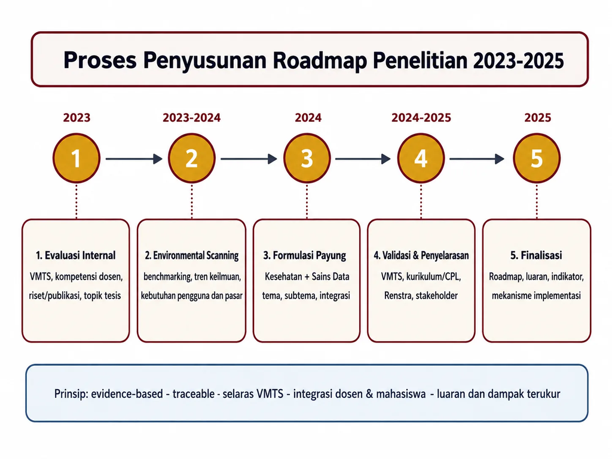

Gambar 1

### Proses Penyusunan Roadmap Penelitian 2023–2025

Visual ini menegaskan bahwa roadmap disusun sebagai proses bertahap, bukan keputusan satu kali. Urutannya bergerak dari evaluasi internal, scanning eksternal, formulasi payung, validasi dan penyelarasan, hingga finalisasi; setiap tahap menghasilkan keluaran yang menjadi input tahap berikutnya. Struktur ini memperkuat sifat evidence-based dan traceable dari roadmap.

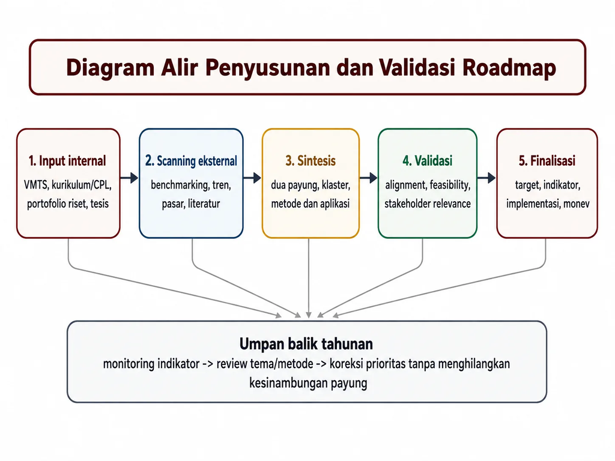

Gambar 2

### Diagram Alir Penyusunan dan Validasi Roadmap

Diagram alir menunjukkan hubungan logis antara input internal, benchmarking dan tren eksternal, sintesis tema, validasi, dan finalisasi. Adanya umpan balik tahunan berarti roadmap diperlakukan sebagai sistem adaptif: tema dan metode dapat dikoreksi berdasarkan indikator tanpa kehilangan kesinambungan dua payung utama.

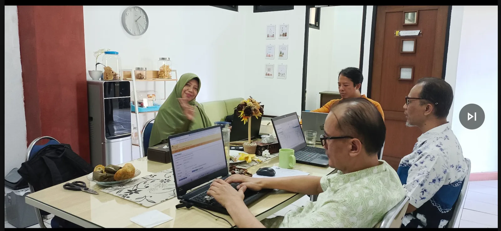

Gambar 3

### Dokumentasi internal pembahasan Program Studi

Foto memperlihatkan forum kerja internal dengan penggunaan laptop dan dokumen digital sebagai media pembahasan. Dokumentasi ini mendukung adanya proses diskusi kolaboratif Program Studi, namun tidak digunakan untuk menetapkan tanggal, agenda spesifik, atau identitas peserta di luar informasi yang dapat diverifikasi.

[figure not shown]

Gambar 4

### Dokumentasi internal pembahasan Program Studi

Sudut dokumentasi kedua memperlihatkan pembahasan dalam kelompok kecil dan suasana kerja yang memungkinkan penelaahan dokumen secara langsung. Foto ini memperkuat bukti adanya deliberasi internal, tetapi tetap diperlakukan secara hati-hati karena tanggal kegiatan tidak tersedia pada berkas.

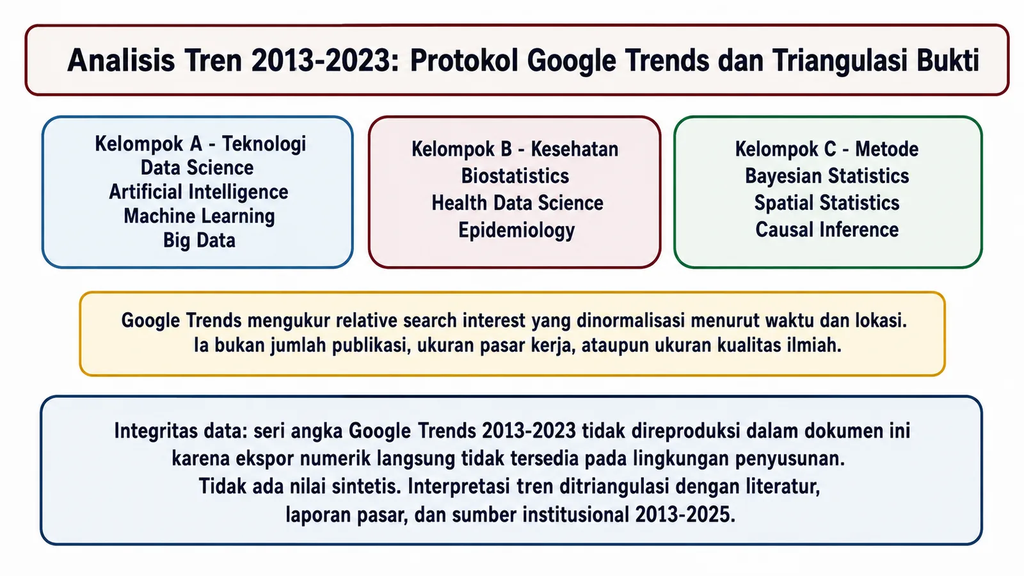

Gambar 5

### Analisis Tren 2013–2023: Google Trends dan Triangulasi Bukti

Pengelompokan istilah menjadi teknologi, kesehatan, dan metode membuat analisis tren lebih interpretabel dan menghindari perbandingan keyword yang skalanya terlalu berbeda. Pesan utama gambar adalah bahwa Google Trends hanya menjadi sinyal minat relatif; keputusan roadmap harus ditriangulasi dengan literatur, kebutuhan pasar, dan sumber institusional.

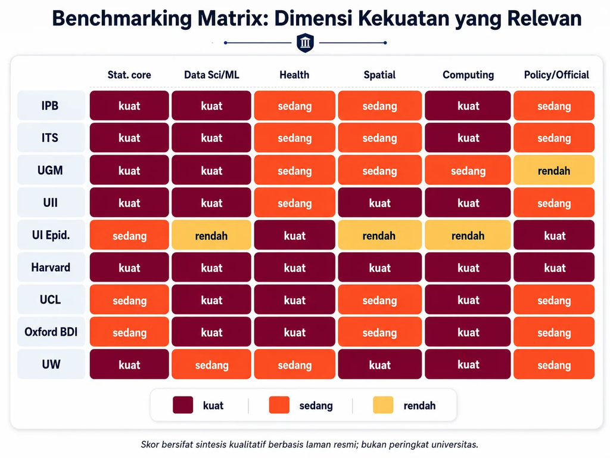

Gambar 6

### Benchmarking Matrix: Dimensi Kekuatan yang Relevan

Matriks benchmarking memperlihatkan bahwa tidak ada satu institusi yang dijadikan model tunggal. Setiap benchmark memberi pelajaran berbeda: kekuatan statistical core, data science/ML, kesehatan, spasial, computing, dan policy/official statistics. Karena itu positioning Unpad dibangun sebagai sintesis kekuatan yang relevan, bukan meniru struktur program lain.

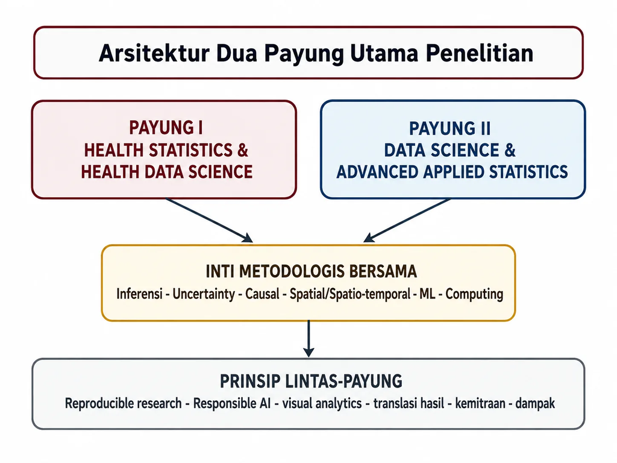

Gambar 7

### Arsitektur Dua Payung Utama Penelitian

Dua payung utama tidak dirancang sebagai silo. Health Statistics & Health Data Science dan Data Science & Advanced Applied Statistics bertemu pada inti metodologis bersama - inferensi, uncertainty, causal reasoning, spatial/spatio-temporal, machine learning, dan computing - serta dipayungi prinsip reproducible research, responsible AI, visual analytics, translasi hasil, kemitraan, dan dampak.

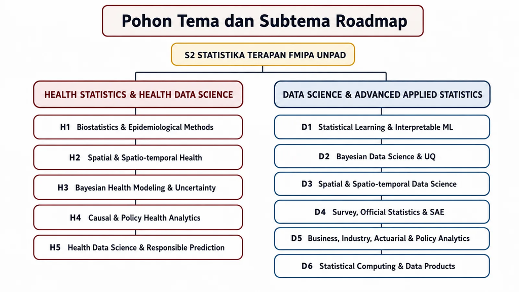

Gambar 8

### Pohon Tema dan Subtema Roadmap

Pohon tema menerjemahkan dua payung menjadi home cluster yang operasional. Struktur ini membantu pemetaan riset dosen, mata kuliah, dan tesis, namun tetap membuka irisan lintas-klaster; satu penelitian dapat terhubung ke lebih dari satu tema apabila alasan metodologis dan aplikasinya jelas.

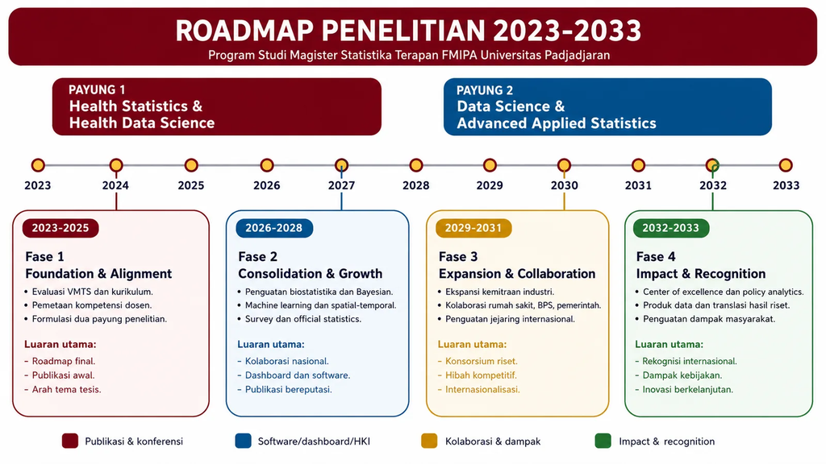

Gambar 9

### Roadmap Penelitian 2023–2033

Roadmap 2023-2033 membagi pengembangan ke dalam empat fase: foundation and alignment, consolidation and growth, expansion and collaboration, serta impact and recognition. Urutan tersebut menunjukkan bahwa rekognisi internasional dan dampak ditempatkan sebagai hasil dari fondasi evidence, penguatan kapasitas, dan kolaborasi yang dibangun secara bertahap.

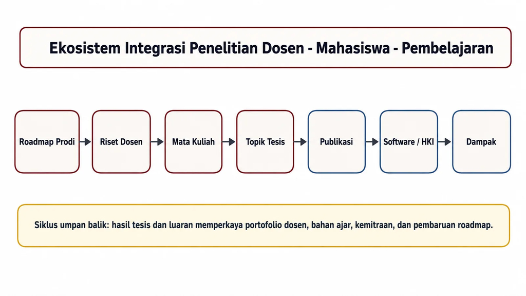

Gambar 10

### Ekosistem Integrasi Penelitian Dosen–Mahasiswa–Pembelajaran

Ekosistem integrasi menunjukkan rantai nilai penelitian dari roadmap prodi ke riset dosen, mata kuliah, topik tesis, publikasi, software/HKI, hingga dampak. Umpan balik dari tesis dan luaran kembali memperkaya portofolio dosen, bahan ajar, kemitraan, dan pembaruan roadmap sehingga pembelajaran dan penelitian saling menguatkan.

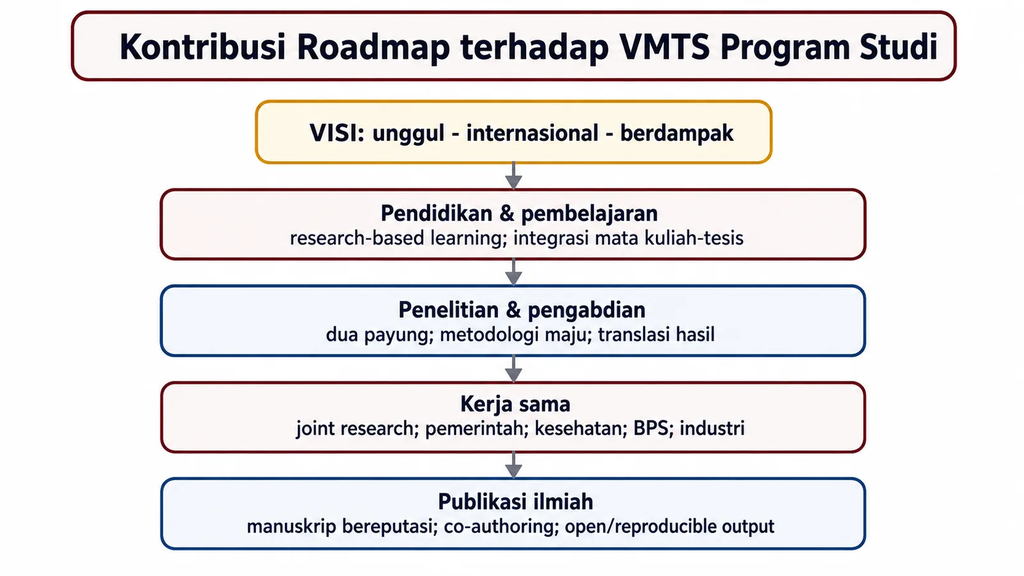

Gambar 11

### Kontribusi Roadmap terhadap VMTS Program Studi

Visual ini menunjukkan bahwa roadmap bukan aktivitas penelitian yang berdiri sendiri, melainkan instrumen untuk mendukung VMTS. Research-based learning memperkuat pendidikan; dua payung dan translasi hasil memperkuat penelitian dan pengabdian; joint research memperkuat kerja sama; dan manuskrip bereputasi serta open/reproducible output memperkuat publikasi ilmiah.

[figure not shown]

Gambar 12

### Rapat tindak lanjut/evaluasi Program Studi 15 Juli 2026

Foto bertanggal 15 Juli 2026 diposisikan sebagai bukti tindak lanjut dan evaluasi setelah roadmap dinyatakan final pada 2025. Penempatan ini penting untuk menjaga integritas kronologi sekaligus menunjukkan bahwa roadmap dilanjutkan melalui mekanisme monitoring, evaluasi, dan pembaruan setelah fase penyusunan selesai.

Naskah akademik

## Narasi Akademik BAB I–XI

Isi akademik disajikan secara berurutan dari BAB I sampai BAB XI untuk pembacaan langsung dari atas ke bawah.

# BAB I PENDAHULUAN

## 1.1 Latar Belakang

Statistika terapan berada pada posisi strategis karena problem modern semakin ditandai oleh data yang besar, heterogen, berstruktur ruang-waktu, berasal dari survei maupun sumber administratif/digital, dan menuntut pengambilan keputusan yang dapat dipertanggungjawabkan. Dalam konteks tersebut, kontribusi statistika tidak berhenti pada prediksi. Program magister perlu menegaskan nilai tambah berupa desain pengumpulan data, inferensi, validasi, kuantifikasi ketidakpastian, interpretabilitas, kausalitas, reproducibility, dan translasi hasil menjadi keputusan.

Pada level institusional, Renstra Unpad 2020-2024 dan dokumen FMIPA menjadi landasan agar pengembangan penelitian program studi konsisten dengan arah universitas dan fakultas. Roadmap Penelitian dan Pengabdian FMIPA 2021-2025 menegaskan pentingnya peta jalan fakultas sebagai implementasi arah riset universitas dan sebagai pemersatu kegiatan penelitian.

Roadmap Program Studi S2 Statistika Terapan karena itu dirancang bukan sebagai katalog metode, tetapi sebagai arsitektur riset yang menghubungkan dua payung prioritas - Kesehatan dan Sains Data - dengan kompetensi statistika terapan dan bidang aplikasi yang tercantum dalam VMTS: bisnis dan industri, sosial, aktuaria, biostatistik, dan sains data.

## 1.2 Tujuan Penyusunan Roadmap

• menetapkan arah dan kekhasan penelitian Program Studi secara jelas dan dapat ditelusuri;

• menyelaraskan penelitian dengan VMTS, kurikulum/CPL, Renstra/RIP fakultas dan universitas;

• mengintegrasikan penelitian dosen, mata kuliah, tesis mahasiswa, publikasi, software/HKI, dan dampak;

• menyediakan dasar prioritisasi tema, kemitraan, dan investasi kapasitas metodologis;

• menyediakan indikator monitoring, evaluasi, dan pembaruan roadmap 2023-2033;

• memperkuat bukti Elemen C01 Penelitian untuk evaluasi dan akreditasi.

## 1.3 Landasan Penyusunan

Landasan internal mencakup VMTS Program Studi, kurikulum dan CPL, rekam jejak penelitian dan tesis yang tersedia, serta dokumentasi proses akademik. Landasan eksternal mencakup Renstra Unpad 2020-2024, Renstra FMIPA 2020-2024, Roadmap Penelitian dan Pengabdian FMIPA 2021-2025, benchmarking program relevan, perkembangan keilmuan, serta kebutuhan pasar kerja dan institusi pengguna.

## 1.4 Ruang Lingkup

Ruang lingkup roadmap mencakup proses penyusunan 2023-2025, environmental scanning, benchmarking, formulasi dua payung penelitian, tema dan subtema, metode prioritas, bidang aplikasi, integrasi dosen dan mahasiswa, target luaran, implementasi 2023-2033, serta mekanisme monitoring dan evaluasi.

## 1.5 Metodologi Penyusunan

Metode penyusunan menggunakan pendekatan triangulasi: (i) evidence internal; (ii) alignment dengan dokumen strategis; (iii) benchmarking; (iv) scanning tren keilmuan dan pasar; (v) sintesis metodologis; dan (vi) validasi implementabilitas. Pendekatan ini sengaja memisahkan fakta, interpretasi, rekomendasi, dan target.

| Kategori | Makna dalam dokumen | Perlakuan |
| --- | --- | --- |
| Fakta terverifikasi | Didukung dokumen/foto/sumber resmi yang dapat ditelusuri | Dinyatakan sebagai fakta dan diberi sumber. |
| Informasi internal | Diberikan oleh Program Studi dalam proses penyusunan | Dipakai sebagai sumber primer; disarankan sinkronisasi dengan dokumen pengesahan. |
| Interpretasi | Sintesis penulis dari beberapa bukti | Dinyatakan sebagai analisis, bukan kejadian historis. |
| Rekomendasi/target | Arah implementasi ke depan | Diberi label usulan dan/atau perlu validasi internal. |

# BAB II PROFIL DAN ARAH STRATEGIS PROGRAM STUDI

## 2.1 Profil S2 Statistika Terapan

Program Studi Magister Statistika Terapan ditempatkan sebagai program yang mengembangkan kemampuan analisis statistik tingkat lanjut untuk penyelesaian masalah nyata. Kekhasannya tidak didefinisikan oleh satu algoritme, melainkan oleh kemampuan mengintegrasikan formulasi masalah, desain data, pemodelan, inferensi, komputasi, interpretasi, dan komunikasi hasil dalam konteks aplikasi.

## 2.2 VMTS

Visi Program Studi yang digunakan dalam penyusunan roadmap adalah:

[output not shown]

Misi yang menjadi rujukan integrasi penelitian adalah:

• 1. Menyelenggarakan pendidikan dan pembelajaran Magister Statistika dengan fokus pada pengembangan dan penerapan statistika di bidang bisnis industri, sosial, aktuaria, biostatistik, dan sains data.

• 2. Melaksanakan penelitian yang mendukung pengembangan statistika dan memberikan dampak positif bagi masyarakat.

• 3. Menjalin kerja sama dalam bidang pendidikan dan penelitian dengan berbagai pihak di tingkat nasional maupun internasional.

• 4. Mempublikasikan hasil-hasil penelitian dalam bentuk publikasi ilmiah bereputasi.

[output not shown]

## 2.3 Kekhasan Program Studi

Positioning yang direkomendasikan adalah statistical data science: sains data yang tetap berpijak pada inferensi statistik, kuantifikasi ketidakpastian, desain sampel/eksperimen, struktur spasial dan temporal, kausalitas, serta reproducible computing. Kesehatan berfungsi sebagai domain unggulan yang menuntut ketelitian inferensial, sedangkan bisnis-industri, sosial, aktuaria, official statistics, lingkungan, dan kebijakan menjadi domain aplikasi lintas-payung.

Dengan positioning tersebut, Program Studi tidak bersaing sebagai program rekayasa AI generik. Nilai pembeda justru berada pada kemampuan menjawab tiga pertanyaan sekaligus: seberapa akurat model memprediksi, seberapa kuat bukti inferensinya, dan seberapa dapat dipertanggungjawabkan keputusan yang dihasilkan.

## 2.4 Kompetensi dan Modal Akademik

Modal akademik yang dibutuhkan untuk mengoperasionalkan roadmap meliputi fondasi probabilitas dan inferensi, regresi dan multivariat lanjut, time series, statistik spasial, Bayesian modeling, survey sampling, statistical learning, komputasi R/Python, visualisasi, serta kemampuan membaca substansi domain. Pemetaan kepakaran individual dosen tidak diisi berdasarkan asumsi; bagian tersebut disediakan sebagai matriks validasi internal pada Bab VIII.

# BAB III PROSES PENYUSUNAN ROADMAP 2023-2025

## 3.1 Tahapan Penyusunan

Roadmap direkonstruksi sebagai proses bertahap 2023-2025. Rekonstruksi ini mengikuti urutan akademik yang konsisten dengan kebutuhan penyusunan roadmap, tetapi tidak dimaksudkan sebagai klaim bahwa setiap sub-kegiatan telah terlaksana pada tanggal tertentu apabila bukti tanggal/agendanya tidak tersedia.

| Periode | Tahap | Cakupan | Keluaran |
| --- | --- | --- | --- |
| 2023 | Evaluasi internal dan identifikasi kompetensi | Evaluasi VMTS; pemetaan kompetensi; riset/publikasi; tesis; kebutuhan kekhasan prodi. | Inventarisasi awal dan gap analysis. |
| 2023-2024 | Environmental scanning dan benchmarking | Benchmark program; tren data science/health analytics; pasar; pengguna lulusan; literatur. | Bukti eksternal dan lessons learned. |
| 2024 | Perumusan payung dan klaster | Rapat/FGD; integrasi riset dosen-mahasiswa; formulasi Kesehatan dan Sains Data. | Draft payung, tema, subtema. |
| 2024-2025 | Validasi dan penyelarasan | VMTS; kurikulum/CPL; Renstra/RIP; stakeholders; peluang kerja sama. | Draft tervalidasi secara konseptual. |
| 2025 | Finalisasi roadmap | Struktur; luaran; publikasi; software/HKI; kolaborasi; dampak; Monev. | Dokumen roadmap final 2025. |

Narasi kegiatan penyusunan. Pada tahap awal, kegiatan diarahkan pada evaluasi VMTS, kurikulum/CPL, kompetensi dan rekam jejak riset, serta pemetaan topik tesis untuk mengenali modal dan gap Program Studi. Tahap berikutnya menggunakan environmental scanning, benchmarking, perkembangan keilmuan, dan kebutuhan pengguna untuk menguji relevansi arah yang dipilih.

Hasil evaluasi dan scanning kemudian disintesis melalui pembahasan internal menjadi dua payung - Kesehatan dan Sains Data - beserta tema, subtema, metode, dan bidang aplikasi. Validasi dilakukan melalui penyelarasan dengan VMTS, kurikulum/CPL, dokumen strategis, stakeholder relevance, dan implementability. Finalisasi tahun 2025 menetapkan struktur roadmap, luaran, indikator, serta mekanisme monitoring dan evaluasi.

## 3.2 Rapat Internal

Rapat internal berfungsi untuk menguji keterhubungan antara tema penelitian, kapasitas metodologis, kebutuhan pembelajaran, tesis mahasiswa, dan target luaran. Karena daftar notulen dan tanggal rapat 2023-2025 belum seluruhnya tersedia pada bahan yang diterima, dokumen ini tidak menetapkan tanggal atau peserta spesifik di luar informasi yang dapat diverifikasi.

## 3.3 Focus Group Discussion

FGD dalam kerangka penyusunan roadmap diarahkan untuk membahas kelayakan dua payung, irisan antar-klaster, potensi mitra, mekanisme pembimbingan tesis, serta konsistensi dengan VMTS. Informasi tanggal, undangan, daftar hadir, dan notulen FGD memerlukan validasi internal apabila akan dipakai sebagai bukti audit/akreditasi.

## 3.4 Dokumentasi Kegiatan

Narasi kegiatan rapat/pembahasan. Dokumentasi memperlihatkan kegiatan kerja internal dalam format diskusi meja yang didukung laptop dan dokumen digital. Secara substantif, forum semacam ini digunakan untuk membaca ulang keterkaitan antara arah penelitian, bukti rekam jejak, kebutuhan pembelajaran, tesis mahasiswa, dan target luaran. Karena metadata tanggal dua foto tidak tersedia, narasi ini hanya menjelaskan fungsi akademik kegiatan dan tidak mengklaim kronologi spesifik.

[output not shown]

## 3.5 Penyelarasan Internal

Penyelarasan internal difokuskan pada konsistensi antara payung riset, VMTS, kurikulum/CPL, struktur tesis, serta target publikasi dan inovasi. Prinsip pentingnya adalah traceability: setiap topik penelitian mahasiswa idealnya dapat dilacak ke klaster roadmap, dosen pembimbing, metode, mata kuliah pendukung, dan target luaran, tanpa mengurangi kebebasan akademik mahasiswa untuk mengembangkan pertanyaan baru.

# BAB IV ENVIRONMENTAL SCANNING

## 4.1 Perkembangan Statistika Terapan

Perkembangan statistika terapan memperlihatkan konvergensi antara inferensi klasik, komputasi skala besar, Bayesian modeling, machine learning, causal inference, dan analisis data berstruktur kompleks. Benchmark departemen statistika yang kuat menunjukkan bahwa identitas statistik tetap relevan ketika diintegrasikan dengan data science, bukan digantikan olehnya.

## 4.2 Perkembangan Data Science

Laporan World Economic Forum 2023 menempatkan Data Analysts and Scientists, Big Data Specialists, dan AI/Machine Learning Specialists dalam kelompok peran yang berkembang seiring adopsi teknologi data dan AI. Bukti ini tidak digunakan sebagai alasan untuk mengejar istilah populer semata, tetapi untuk menegaskan kebutuhan kompetensi statistik, komputasi, dan pengambilan keputusan berbasis data.

## 4.3 Perkembangan Health Data Science

Health data science berkembang sebagai integrasi statistika, epidemiologi, informatika kesehatan, machine learning, dan tata kelola data. WHO menekankan penguatan pengumpulan, analisis, dan penggunaan data serta evidence untuk menghasilkan dampak kesehatan. Dalam ranah AI untuk kesehatan, WHO juga menekankan governance dan prinsip etis agar penggunaan AI memberi manfaat publik dan mengelola risiko.

## 4.4 Tren Riset

Secara metodologis, empat arus penting bagi roadmap adalah: (1) Bayesian computation yang membuat hierarchical and latent Gaussian models lebih operasional; (2) spatial/spatio-temporal modeling untuk data lingkungan dan kesehatan; (3) integrasi causal inference dengan machine learning; serta (4) responsible/interpretable AI. INLA merupakan salah satu perkembangan penting untuk aproksimasi inferensi Bayesian pada latent Gaussian models (Rue, Martino, & Chopin, 2009), sedangkan R-INLA menyediakan kerangka praktis untuk spatial Bayesian modeling (Lindgren & Rue, 2015).

Dalam health analytics, causal machine learning memperluas fokus dari prediksi menuju estimasi efek intervensi dan reasoning kausal pada sistem pendukung keputusan klinis (Sanchez et al., 2022). Untuk AI secara umum, NIST AI RMF 1.0 merumuskan karakteristik sistem yang dapat dipercaya, termasuk valid-reliable, accountable-transparent, explainable-interpretable, privacy-enhanced, dan fair.

## 4.5 Google Trends 2013-2023

Google Trends dapat digunakan sebagai sinyal minat pencarian publik terhadap istilah tertentu. Google menjelaskan bahwa data dinormalisasi menurut waktu dan lokasi sehingga merepresentasikan popularitas relatif, bukan volume pencarian absolut. Karena itu, Google Trends tidak boleh disamakan dengan jumlah publikasi, kebutuhan tenaga kerja, atau kualitas keilmuan.

Pada lingkungan penyusunan dokumen ini, seri numerik Google Trends 2013-2023 tidak dapat diekspor secara langsung dan dapat diaudit. Sesuai prinsip non-fabrikasi, dokumen tidak mengisi nilai indeks sintetis. Triangulasi dilakukan dengan studi Data Science Journal 2023 yang menggunakan pendekatan scientometric dan Google Trends untuk meninjau perkembangan data science, serta dengan laporan pasar dan sumber institusional.

| Tema | Sintesis tren | Bukti triangulasi | Implikasi roadmap |
| --- | --- | --- | --- |
| Data Science / ML / AI | Menguat sebagai ekosistem teknologi dan pekerjaan | WEF 2023; studi perkembangan data science 2023 | Prioritaskan statistical learning, computing, interpretability; hindari positioning AI generik. |
| Health Data Science | Berkembang bersama digital health dan kompleksitas data kesehatan | WHO; UCL; Oxford; Harvard | Jadikan kesehatan domain unggulan yang menguji rigor inferensial dan responsible analytics. |
| Bayesian / Spatial | Metode mapan dengan ekspansi komputasional dan aplikasi | Rue et al. 2009; Lindgren & Rue 2015; benchmark | Pertahankan sebagai signature method lintas kesehatan, lingkungan, sosial, dan risiko. |
| Causal Inference | Meningkat relevansinya pada evaluasi intervensi dan ML | Sanchez et al. 2022; Harvard | Bangun klaster causal & policy analytics. |
| Official Statistics | Modernisasi melalui big data, ML, data science | UN-CEBD; BPS; UNECE | Perkuat survey sampling, SAE, administrative/alternative data, quality framework. |

## 4.6 Kebutuhan Pasar Kerja

Kebutuhan pasar kerja perlu dibedakan dari popularitas istilah. WEF 2023 memperkirakan permintaan terhadap kelompok peran Data Analysts and Scientists, Big Data Specialists, Business Intelligence Analysts, database/network professionals, dan data engineers tumbuh 30-35% pada 2023-2027, didorong adopsi teknologi yang bergantung pada big data. Temuan tersebut mendukung kebutuhan keterampilan analytical thinking, data modeling, computation, dan AI/ML, tetapi bukan bukti tunggal untuk desain kurikulum.

Dalam konteks Indonesia dan official statistics, berdirinya Regional Hub on Big Data and Data Science for Asia and the Pacific di Jakarta menunjukkan kebutuhan terhadap riset metode baru, capacity building statisticians/data scientists, dan modernisasi statistik resmi. UNECE juga mendokumentasikan eksplorasi machine learning oleh organisasi statistik untuk meningkatkan relevansi dan kualitas official statistics.

## 4.7 Implikasi bagi Program Studi

• Sains Data harus diposisikan sebagai statistical data science: kuat pada modeling, uncertainty, causal reasoning, validation, dan reproducibility.

• Kesehatan layak menjadi payung utama karena menggabungkan masalah berdampak tinggi dengan kebutuhan rigor metodologis dan governance.

• Spatial/spatio-temporal dan Bayesian modeling menjadi jembatan metodologis kedua payung.

• Survey sampling, official statistics, dan small area estimation tetap strategis, terutama karena ekosistem BPS/UN di Indonesia.

• Responsible AI dan reproducible research perlu menjadi prinsip lintas-klaster, bukan tema tambahan yang terpisah.

# BAB V BENCHMARKING

## 5.1 Metode Benchmarking

Benchmarking dilakukan terhadap program/departemen yang memiliki bukti relevan pada Statistics, Applied Statistics, Biostatistics, Data Science, Health Data Science, atau Statistical Science. Pemilihan tidak didasarkan pada reputasi umum, tetapi pada kesesuaian fokus dan informasi yang tersedia di laman resmi institusi. Akses sumber dilakukan pada 8 Agustus 2026; saat sumber saat ini merefleksikan kondisi yang mungkin telah berubah pasca-2025, dokumen hanya mengambil pelajaran struktural, bukan menganggapnya sebagai kondisi historis 2025.

## 5.2 Benchmark Nasional

| Institusi | Program/Unit | Fokus | Kekhasan | Relevansi untuk Unpad |
| --- | --- | --- | --- | --- |
| IPB University | Master Statistics and Data Science | Integrasi statistical theory, data science, ML, modeling, visualization, decision-making. | Statistical data science yang eksplisit dan lintas-domain. | Memperkuat positioning statistik sebagai fondasi data science. |
| ITS | S2 Statistika | Statistika dan Sains Data berbasis komputasi; aplikasi industri, bisnis, ekonomi, sosial, kesehatan, lingkungan. | Keterkaitan statistik-komputasi-aplikasi luas. | Relevan dengan domain VMTS dan orientasi komputasi. |
| UGM | Statistics and Data Science | Big data analytics, ML/AI, statistical modeling & inference, business/industry. | Fokus eksplisit pada statistics + data science. | Pelajaran: core statistical inference tetap terlihat di tengah agenda AI/ML. |
| UII | Magister Statistika | Kurikulum industri/global skills; Big Data, analisis spasial; rumpun BISA dan SDSB. | Kombinasi bisnis-industri-sosial-aktuaria dengan spatial/data science/bioinformatics. | Dekat dengan spektrum aplikasi Unpad; useful untuk diferensiasi klaster. |
| Universitas Indonesia | Master of Epidemiology | Epidemiologi, biostatistik, clinical/community/applied epidemiology, publikasi dan dampak kesehatan. | Penguatan domain kesehatan dan translasi evidence. | Benchmark domain untuk Health Statistics; bukan benchmark program statistika. |

## 5.3 Benchmark Internasional

| Institusi | Program/Unit | Fokus | Kekhasan | Relevansi untuk Unpad |
| --- | --- | --- | --- | --- |
| Harvard T.H. Chan | Biostatistics | Bayesian, causal inference, trials, EHR, high-dimensional, ML/AI, longitudinal/spatio-temporal, survival. | Spektrum metodologis modern yang tetap berakar pada biostatistics. | Referensi kuat untuk Payung Kesehatan. |
| University College London | Health Data Science MSc | EHR/complex data; health informatics; clinical epidemiology; AI/ML; biomedical statistics. | Integrasi health data, methods, and applied study design. | Menunjukkan health data science sebagai interdisiplin yang statistik-sentris. |
| University of Oxford - BDI | Health Data Science | Statistics, machine learning, data management, ethics; biomedical/population health ecosystem. | Etika sebagai vertical theme dan integrasi multidisiplin. | Menguatkan responsible health data science. |
| University of Washington | Department of Statistics | Bayesian inference, spatial statistics, statistical computing, time series, social science methodology, interdisciplinary collaboration. | Kedalaman metodologi plus jejaring lintas-departemen. | Model untuk menjaga identitas statistics sekaligus kolaboratif. |

## 5.4 Comparative Analysis

| Lesson learned | Benchmark pendukung | Implikasi desain roadmap |
| --- | --- | --- |
| Statistical foundation remains visible | IPB, ITS, UGM, Harvard, UW | Unpad harus menampilkan inference, uncertainty, sampling/design sebagai pembeda data science. |
| Health data science is inherently multidisciplinary | Harvard, UCL, Oxford, UI | Payung Kesehatan perlu menggabungkan biostatistics, epidemiology, causal, spatial, ML dan governance. |
| Computing is infrastructure, not an end goal | IPB, ITS, UCL, UW | R/Python, package, Shiny/Streamlit diarahkan untuk reproducibility dan decision support. |
| Applications create identity when method and impact are linked | ITS, UII, UI | Domain bisnis-industri, sosial, aktuaria dan kesehatan perlu diikat dengan metode dan luaran. |
| Responsible/ethical dimension is increasingly explicit | Oxford, WHO, NIST | Responsible AI menjadi prinsip lintas-payung. |

## 5.5 Lessons Learned

Benchmarking mengarahkan struktur roadmap pada dua keputusan: pertama, mempertahankan identitas statistika melalui inference, uncertainty, design, causal reasoning, dan spatial-temporal structure; kedua, menerapkan identitas tersebut pada dua ekosistem berdampak tinggi, yaitu kesehatan dan sains data lintas-domain.

## 5.6 Positioning S2 Statistika Terapan Unpad

[output not shown]

# BAB VI FORMULASI PAYUNG PENELITIAN

## 6.1 Dasar Penetapan Payung

Penetapan dua payung tidak dimaksudkan untuk memisahkan kelompok dosen secara kaku. Health Statistics & Health Data Science memberi fokus domain dan dampak, sedangkan Data Science & Advanced Applied Statistics memberi ruang metodologis dan lintas-domain. Keduanya bertemu pada inti statistika terapan: inferensi, ketidakpastian, kausalitas, struktur ruang-waktu, data quality, komputasi, dan reproduksibilitas.

## 6.2 Payung I - Health Statistics & Health Data Science

| Kode | Tema | Subtema/metode | Contoh permasalahan aplikasi |
| --- | --- | --- | --- |
| H1 | Biostatistics & Epidemiological Methods | survival; longitudinal; clinical/observational data; epidemiological modeling | outcomes klinis; NCD; infectious disease; cohort/surveillance |
| H2 | Spatial & Spatio-temporal Health | disease mapping; spatial epidemiology; environmental health; space-time models | ketimpangan kesehatan; exposure; surveillance; hotspot |
| H3 | Bayesian Health Modeling & Uncertainty | hierarchical Bayes; latent Gaussian models; INLA; Bayesian prediction | small-area health; rare outcomes; latent risk; uncertainty |
| H4 | Causal & Policy Health Analytics | causal inference; program evaluation; quasi-experimental; target trial thinking | intervensi kesehatan; program evaluation; policy impact |
| H5 | Health Data Science & Responsible Prediction | ML; high-dimensional data; EHR; interpretable prediction; responsible AI | clinical decision support; screening; prognosis; digital health |

## 6.3 Payung II - Data Science & Advanced Applied Statistics

| Kode | Tema | Subtema/metode | Contoh permasalahan aplikasi |
| --- | --- | --- | --- |
| D1 | Statistical Learning & Interpretable ML | supervised/unsupervised; ensembles; regularization; interpretable ML | prediction; classification; segmentation; decision support |
| D2 | Bayesian Data Science & Uncertainty Quantification | Bayesian computation; hierarchical modeling; prediction; model uncertainty | forecasting; risk; latent processes; model combination |
| D3 | Spatial & Spatio-temporal Data Science | geostatistics; point processes; spatial econometrics; space-time models | environment; disaster; regional economy; mobility; resources |
| D4 | Survey, Official Statistics & Small Area Estimation | sampling; SAE; admin/alternative data; data integration; quality | official indicators; poverty; labor; population; policy monitoring |
| D5 | Business, Industry, Actuarial & Policy Analytics | forecasting; risk; actuarial; industrial statistics; economics/policy | demand; quality; insurance; finance; productivity; policy |
| D6 | Statistical Computing, Reproducibility & Data Products | R/Python; packages; simulation; dashboard; workflow; versioning | reproducible analysis; Shiny/Streamlit; data products; DSS |

## 6.4 Tema dan Subtema

Tema berfungsi sebagai home cluster untuk perencanaan. Sebuah penelitian dapat berada pada lebih dari satu tema apabila ada alasan metodologis yang jelas. Contoh: disease mapping dengan INLA berada pada H2 dan H3; small area estimation berbasis Bayesian untuk indikator kesehatan dapat menghubungkan H3 dan D4; causal ML untuk evaluasi program kesehatan menghubungkan H4, H5, dan D1.

## 6.5 Metode Prioritas

• Bayesian hierarchical modeling dan latent Gaussian models;

• spatial, spatio-temporal, geostatistical, dan point process models;

• causal inference dan program evaluation;

• survey sampling, data integration, dan small area estimation;

• statistical learning, machine learning, dan interpretable prediction;

• time series, forecasting, risk dan actuarial analytics;

• statistical computing, simulation, reproducible research, dan visual analytics.

## 6.6 Bidang Aplikasi

Bidang aplikasi prioritas mengikuti VMTS dan peluang dampak: kesehatan; bisnis dan industri; sosial dan kependudukan; aktuaria dan risiko; official statistics; kebijakan publik; lingkungan dan kebencanaan. Prioritas aplikasi tidak mengubah inti program sebagai Magister Statistika Terapan.

# BAB VII ROADMAP PENELITIAN 2023-2033

## 7.1 Fase 2023-2025 - Foundation & Alignment

Fase pertama merupakan periode pembentukan fondasi roadmap. Kegiatan diarahkan pada evaluasi VMTS dan kurikulum/CPL, pemetaan kompetensi dan rekam jejak dosen, pemetaan topik tesis dan publikasi, environmental scanning, benchmarking, serta formulasi dua payung Kesehatan dan Sains Data. Fase ini berakhir pada finalisasi roadmap tahun 2025 dan penetapan kerangka traceability antara payung, tema, metode, mahasiswa, luaran, dan dampak.

## 7.2 Fase 2026-2028 - Consolidation & Growth

Fase kedua berfokus pada konsolidasi dan pertumbuhan klaster. Prioritasnya adalah memperkuat biostatistika, Bayesian modeling, machine learning, spatial/spatio-temporal statistics, survey dan official statistics; menstandardisasi reproducible workflow; memperluas keterlibatan mahasiswa melalui tesis dan co-authoring; serta menghasilkan dashboard, software, dan publikasi bereputasi.

## 7.3 Fase 2029-2031 - Expansion & Collaboration

Fase ketiga memperluas kolaborasi pada level problem ownership, data governance, joint supervision, dan co-authored output. Jejaring diarahkan pada perguruan tinggi, pemerintah, BPS, rumah sakit/instansi kesehatan, industri, dan mitra internasional. Luaran prioritas berupa konsorsium riset, hibah kompetitif, publikasi kolaboratif, software/data product, serta aktivitas internasionalisasi yang dapat ditelusuri.

## 7.4 Fase 2032-2033 - Impact & Recognition

Fase keempat menekankan impact and recognition. Program Studi diarahkan mematangkan ekosistem center of excellence, policy analytics, produk data, dan translasi hasil riset. Indikatornya mencakup rekognisi internasional, penggunaan software/data product oleh mitra, kontribusi pada kebijakan atau pengambilan keputusan, serta dokumentasi dampak masyarakat yang dapat diverifikasi.

## 7.5 Visual Roadmap

| Fase | Fokus | Metode prioritas | Mahasiswa | Luaran | Outcome/dampak |
| --- | --- | --- | --- | --- | --- |
| 2023-2025 | Foundation & Alignment: evaluasi internal; scanning; formulasi dua payung; finalisasi roadmap | Bayesian; spatial; ML; causal; survey/SAE; computing | Pemetaan tesis dan publikasi; baseline keterlibatan mahasiswa | Roadmap final; publikasi awal; arah tema tesis | Fondasi evidence, traceability, dan baseline indikator |
| 2026-2028 | Consolidation & Growth: penguatan klaster dan reproducibility | Biostatistics; Bayesian; ML; spatial-temporal; survey/official statistics | Tesis terarah; co-authoring; tim mahasiswa lintas tema | Publikasi bereputasi; dashboard; software; HKI | Kapasitas riset meningkat dan kolaborasi nasional menguat |
| 2029-2031 | Expansion & Collaboration: perluasan kemitraan dan jejaring | Integrasi spatio-temporal + causal/ML; data integration | Joint supervision; kolaborasi lintas institusi | Konsorsium riset; hibah kompetitif; publikasi bersama; data product | Kolaborasi aktif dan internasionalisasi meningkat |
| 2032-2033 | Impact & Recognition: translasi hasil, policy analytics, center of excellence | Advanced hierarchical/causal/AI dengan responsible governance | International mentoring/co-supervision bila tersedia | Reusable software/data; policy product; international co-authorship | Rekognisi internasional dan kasus dampak terverifikasi |

# BAB VIII INTEGRASI DOSEN, MAHASISWA DAN PEMBELAJARAN

## 8.1 Matriks Dosen-Riset

Matriks dosen-riset berikut diperbarui menggunakan evidence publikasi bersama dosen-mahasiswa yang diberikan dalam proses penyusunan. Dataset tersebut memuat 64 luaran pada 2022-2026, melibatkan 62 mahasiswa, termasuk 25 jurnal internasional dan 12 luaran Q1/Q2. Pemetaan tema dan metode di bawah ini merupakan sintesis dari judul dan karakter metodologis publikasi; validasi akhir terhadap portofolio lengkap dosen dan data hibah tetap dilakukan sebelum pengesahan.

Sumber publikasi dosen: https://statistika-unpad.github.io/pasca-statistika-web/?v=obe-report-20260808#publikasi-dosen

| Dosen | Payung | Tema | Metode | Bidang aplikasi | Keterlibatan mahasiswa | Target luaran |
| --- | --- | --- | --- | --- | --- | --- |
| Dr. I Gede Nyoman Mindra Jaya, M.Si. | I & II | H2, H3, D1, D2, D3 | Bayesian spatio-temporal; SPDE/INLA; kriging; ML/LASSO | stunting; PM2.5; gempa; emisi karbon | Kiki Amelia; Tafia Hasna Putri; Dila Fitriani Azuri; Fariza Alamanda Putri; dll. | publikasi bereputasi; software/dashboard; reproducible code |
| Dr. Bertho Tantular, M.Si. | I & II | H2, D1, D3, D5 | spatial mapping; cokriging; ML; policy forecasting | stunting; kualitas udara/PM2.5; kebijakan harga pangan | Kiki Amelia; Leivina Saliaputri; Fariza Alamanda Putri; Fellita Odelia Wibowo; dll. | publikasi bersama; model/decision support; data product |
| Dr. Irlandia Ginanjar, M.Si. | I & II | H4, D1, D4 | multivariate analysis; correspondence analysis; clustering; EBLUP-FH | stunting; sanitasi; clean water; official/social statistics | Dhanti Aurilia Pratiwi; Renata Syifa Kristanto; Leivina Saliaputri; Theresia Samaria Nauli; dll. | publikasi; metodologi multivariat; policy/official statistics output |
| Dr. Gumgum Darmawan, M.Si. | II (+ H5) | D1, D5, D6, H5 | time series; SARIMA/ARFIMA/SSA; ML; CNN-LSTM | transportasi; pariwisata; PM2.5; pertanian/kebijakan | Fellita Odelia Wibowo; Aisha Kusuma Putri; Gracia J. C. Hutabarat; Tafia Hasna Putri; dll. | publikasi bereputasi; forecasting tools; software/dashboard |
| Dr. Anindya Apriliyanti Pravitasari, M.Si. | I & II | H5, D1, D6 | BiLSTM/GRU; NLP; BERTopic; clustering; ML | digital health/service; social media; chatbot akademik; political text | Sandrina Najwa; Ibnu Try Rosadi; Najma Rafifah Putri Syallya; Nisa Akbarilah Putri; dll. | publikasi; NLP/ML pipeline; reproducible data product |

## 8.1.1 Evidence Hasil Penelitian Dosen dan Mahasiswa

Evidence publikasi menunjukkan bahwa dua payung roadmap telah memiliki jejak implementasi. Pada Payung I terlihat tema stunting, PM2.5, air quality, Bayesian spatio-temporal, dan health/risk analytics. Pada Payung II terlihat forecasting, machine learning, clustering, NLP, policy analytics, dan official statistics. Keterlibatan mahasiswa pada publikasi tersebut menunjukkan bahwa integrasi roadmap - riset dosen - tesis/pembelajaran - publikasi telah memiliki contoh nyata.

| Tahun | Dosen | Mahasiswa | Evidence publikasi | Jurnal/Prosiding | Scopus |
| --- | --- | --- | --- | --- | --- |
| 2026 | Dr. I Gede Nyoman Mindra Jaya, S.Si., M.Si; Dr. Bertho Tantular, S.Si., M.Si | Kiki Amelia | Mapping and Forecasting District-Level Stunting Dynamics in Indonesia Toward SDG Target 2.2: A Hybrid Bayesian-Machine Learning Spatiotemporal Analysis | Sustainability | Q1 |
| 2026 | Dr. Gumgum Darmawan, S.Si., M.Si; Dr. Bertho Tantular, S.Si., M.Si; Dr. Sri Winarni, S.Si., M.Si | Fellita Odelia Wibowo | Evaluating the Impact of the Government Floor Price Policy (HPP) on Farm-Gate-Level Harvested Dry Paddy (GKP) Price Trends Through Machine Learning-Based Forecasting | Mathematics | Q1 |
| 2023 | Dr. Bertho Tantular, S.Si., M.Si; Prof. Dr. Toni Toharudin, M.Sc | Leivina Saliaputri | Air Quality Mapping in Bandung City | Atmosphere | Q2 |
| 2024 | Dr. I Gede Nyoman Mindra Jaya, S.Si., M.Si; Prof. Dr. Toni Toharudin, M.Sc | Tafia Hasna Putri | Sensitivity analysis of the PC hyperprior for range and standard deviation components in Bayesian Spatiotemporal high-resolution prediction: An application to PM2.5 prediction in Jakarta, Indonesia | International Journal of Data and Network Science | Q1 |
| 2024 | Prof. Dr. Toni Toharudin, M.Sc; Dr. Gumgum Darmawan, S.Si., M.Si; Dr. Defi Yusti Faidah, S.Si., M.Si | Tafia Hasna Putri | Fine-Tuning of Predictive Models CNN-LSTM and CONV-LSTM for Nowcasting PM2.5 Level | IEEE Access | Q1 |
| 2026 | Dr. Irlandia Ginanjar, M.Si; Budhi Handoko, M.Si., Ph.D | Leivina Saliaputri | Why Do Stunting Interventions Remain Unequal in Urban Areas? A Multivariate Analysis of Subdistrict Risk Profiles in Cirebon City, Indonesia | Risk Management and Healthcare Policy | Q1 |
| 2025 | Dr. I Gede Nyoman Mindra Jaya, S.Si., M.Si; Dr. Bertho Tantular, S.Si., M.Si | Fariza Alamanda Putri | Spatiotemporal Cokriging for Modeling and Prediction of PM2.5 Concentrations in Jakarta | IAENG International Journal of Applied Mathematics | Q3 |
| 2025 | Dr. I Gede Nyoman Mindra Jaya, S.Si., M.Si | Dila Fitriani Azuri | Bayesian spatiotemporal stochastic partial differential equation for high-resolution earthquake magnitude mapping: Application to Sumatra Island, Indonesia | MethodsX | Q1 |

## 8.1.2 Evidence Hibah Dosen

Evidence hibah dosen telah diperbarui menggunakan dataset resmi Program Studi pada berkas data/research_grants.json. Dataset tersebut memuat 45 kegiatan pada 2022-2026 dengan total pendanaan Rp2.744.335.000 dan 24 kegiatan memiliki dokumen kontrak yang ditandai tersedia pada sumber. Untuk menjaga integritas kronologi pengesahan Agustus 2025, kegiatan 2022-2025 diperlakukan sebagai baseline/implementasi sampai pengesahan, sedangkan kegiatan 2026 diperlakukan sebagai bukti tindak lanjut dan monitoring pasca-pengesahan.

Sumber hibah riset: https://statistika-unpad.github.io/pasca-statistika-web/?v=obe-report-20260808#hibah-riset

Interpretasi evidence hibah. Portofolio hibah memperlihatkan kesinambungan metode dan domain yang konsisten dengan roadmap: pemodelan kesehatan dan penyakit menular, Bayesian dan geospasial, machine learning/AI, time series dan forecasting, aktuaria/risiko, analisis multivariat, serta statistical computing/data products. Pemetaan payung dan kode tema pada lampiran merupakan sintesis dari judul kegiatan untuk kebutuhan traceability dan perlu dibaca sebagai klasifikasi analitik, bukan label resmi pada kontrak.

| Tahun | Jumlah kegiatan | Nilai pendanaan | Dokumen tersedia | Posisi terhadap pengesahan |
| --- | --- | --- | --- | --- |
| 2022 | 4 | Rp65.000.000 | 0 | Baseline/sampai pengesahan |
| 2023 | 13 | Rp1.380.840.000 | 0 | Baseline/sampai pengesahan |
| 2024 | 7 | Rp297.475.000 | 4 | Baseline/sampai pengesahan |
| 2025 | 17 | Rp844.020.000 | 17 | Baseline/sampai pengesahan |
| 2026 | 4 | Rp157.000.000 | 3 | Pasca-pengesahan |

## 8.1.3 Ringkasan Portofolio Publikasi Dosen

Portal resmi publikasi dosen memuat 124 rekam publik publikasi dosen pada periode 2022-2026 dari 17 dosen. Data publik tersebut bersifat parsial karena kelengkapan penuh memerlukan akses/ekspor resmi SINTA. Ringkasan ini digunakan sebagai bukti outcome penelitian dosen, sedangkan tabel publikasi dosen-mahasiswa pada lampiran digunakan untuk menunjukkan integrasi penelitian dengan mahasiswa.

| Indikator | Nilai | Catatan |
| --- | --- | --- |
| Total rekam publik | 124 | 2022-2026 |
| Dosen dalam dataset | 17 | profil SINTA/Scopus |
| SINTA-Scopus | 80 | rekam publik |
| SINTA-Garuda | 44 | rekam publik |
| WOS profile tersedia | 2 | profil |
| H-Index Scopus tertinggi | 16 | pada dataset publik |

Distribusi publikasi dosen pada dataset publik: 2022 = 7, 2023 = 9, 2024 = 22, 2025 = 66, dan 2026 = 20. Kategori indeks terdiri atas Scopus Q1 = 32, Q2 = 3, Q3 = 30, Q4 = 13, Sinta 2 = 16, Sinta 3 = 11, Sinta 4 = 5, Sinta 5 = 5, dan tidak terindeks = 9.

Sumber data publikasi dosen: https://statistika-unpad.github.io/pasca-statistika-web/?v=obe-report-20260808#publikasi-dosen

## 8.2 Integrasi Tesis

Topik tesis diarahkan melalui katalog problem-method fit, bukan daftar judul baku. Mahasiswa tetap dapat mengusulkan topik baru sepanjang mampu menunjukkan keterkaitan dengan salah satu payung atau menjelaskan alasan akademik untuk topik di luar payung. Proses ini menjaga fokus program tanpa mengurangi inovasi.

## 8.3 Integrasi Mata Kuliah

| Mata kuliah/kelompok | Klaster terkait | Peran metodologis | Contoh integrasi ke tesis/luaran |
| --- | --- | --- | --- |
| Regresi/Multivariat Lanjut | H1, H4, D1, D5 | Modeling, inference, prediction | tesis metodologis/aplikatif; manuscript-ready analysis |
| Analisis Deret Waktu Lanjut | D2, D5 | forecasting, dynamic models, uncertainty | forecasting business/health/risk; reusable code |
| Statistika Spasial | H2, H3, D3 | spatial Bayes, geostatistics, point process | disease/environment/disaster mapping; maps/dashboard |
| Sampling Survey | D4 | design-based/model-assisted; data quality | official/social statistics; SAE/data integration |
| Machine Learning / Sains Data | H5, D1, D6 | statistical learning, validation, interpretability | predictive analytics; reproducible pipeline |
| Proses Stokastik / Aktuaria | D2, D5 | stochastic/risk models | risk and actuarial analytics |
| Seminar/Tesis | Semua | research design, evidence synthesis, communication | thesis -> publication -> product/impact |

## 8.4 Research-Based Learning

Research-based learning menggunakan dataset, masalah, dan workflow yang berasal dari riset dosen/mitra secara terkontrol. Output pembelajaran dapat berupa replication study, simulation note, reproducible notebook, mini-package, atau prototype dashboard. Tidak setiap tugas harus menjadi publikasi; kualitas metodologis dan etika penggunaan data tetap menjadi prioritas.

## 8.5 Kolaborasi

Kolaborasi idealnya dibangun pada level problem ownership dan data governance. Kerja sama hanya dinilai produktif jika menghasilkan aktivitas penelitian yang dapat ditelusuri, keterlibatan mahasiswa, output bersama, atau penggunaan hasil oleh mitra. Hal ini mencegah roadmap bergantung pada MoU yang tidak operasional.

# BAB IX TARGET DAN INDIKATOR KINERJA

## 9.1 Publikasi

Target publikasi perlu menyeimbangkan kualitas, konsistensi, dan kolaborasi. Prioritas adalah jurnal nasional terakreditasi, jurnal internasional, dan jurnal internasional bereputasi sesuai kematangan proyek. Co-authorship mahasiswa didorong jika kontribusinya memenuhi kaidah authorship.

## 9.2 HKI

HKI diarahkan pada software, database, modul, dan karya terkait yang benar-benar memiliki nilai reuse. Pendaftaran HKI bukan pengganti validasi ilmiah, tetapi salah satu kanal perlindungan dan dokumentasi inovasi.

## 9.3 Software dan Data Products

Scientific products mencakup R/Python package, reproducible code, dataset terkurasi, simulation tools, Shiny/Streamlit application, dashboard, dan decision-support system. Prinsip minimal: dokumentasi, version control, lisensi yang sesuai, dan contoh penggunaan.

## 9.4 Kerja Sama

Kategori mitra meliputi perguruan tinggi, pemerintah, BPS, rumah sakit/instansi kesehatan, industri, dan lembaga riset. Target kerja sama harus diukur melalui output riset atau aktivitas bersama, bukan hanya jumlah dokumen perjanjian.

## 9.5 Internasionalisasi

Internasionalisasi dioperasionalkan melalui joint research, co-authorship, visiting/guest research activity, international seminar, co-supervision jika tersedia, serta penyebaran software/data products yang dapat digunakan komunitas internasional.

## 9.6 Dampak

Dampak dicatat melalui impact pathway: problem -> evidence -> product/recommendation -> user -> perubahan keputusan/proses/kapasitas. Bukti dapat berupa surat penggunaan, analytics dashboard, policy brief, testimoni institusi, integrasi ke SOP, atau dokumentasi capacity building.

[output not shown]

# BAB X IMPLEMENTASI, MONITORING DAN EVALUASI

## 10.1 Mekanisme Implementasi

Implementasi tahunan dimulai dari pemetaan proposal riset dan tesis terhadap payung-klaster, penetapan target luaran per proyek, review kebutuhan data/etik, dukungan metodologis, monitoring semesteran, dan dokumentasi outcome. Dashboard internal sederhana dapat digunakan untuk menjaga traceability.

## 10.2 Monitoring Tahunan

| Waktu | Kegiatan | Objek monitoring | Keluaran |
| --- | --- | --- | --- |
| Awal tahun/semester | Pemetaan proyek dan tesis baru | Tema, metode, mahasiswa, mitra, target output | Matriks roadmap terbarui |
| Tengah semester | Progress review | data readiness, model, bottleneck, ethics/governance | catatan tindakan korektif |
| Akhir semester | Output review | manuscript, code, software, dashboard, HKI | evidence repository |
| Akhir tahun | Portfolio review | coverage klaster, kolaborasi, kualitas output, dampak | laporan monev + rekomendasi |
| Dua tahunan | Strategic review | relevansi payung/tema dan perubahan keilmuan | revisi minor roadmap bila diperlukan |

## 10.3 Evaluasi Roadmap

Evaluasi menggunakan empat dimensi: relevance (kesesuaian dengan problem/stakeholder), scientific quality (rigor metodologis), productivity (output terverifikasi), dan impact (penggunaan hasil). Tema yang sedikit digunakan tidak otomatis dihapus; terlebih dahulu dievaluasi apakah kendalanya kapasitas, data, kemitraan, atau memang relevansinya menurun.

## 10.4 Mekanisme Review dan Pembaruan

Roadmap ditinjau ringan setiap tahun dan ditinjau strategis dua tahunan. Perubahan payung utama hanya dilakukan apabila terdapat bukti kuat bahwa arah keilmuan, VMTS, atau kebutuhan stakeholder telah berubah. Dengan demikian, roadmap tetap adaptif tanpa kehilangan kesinambungan identitas.

# BAB XI PENUTUP

Roadmap Penelitian S2 Statistika Terapan FMIPA Universitas Padjadjaran 2025 menempatkan Health Statistics & Health Data Science serta Data Science & Advanced Applied Statistics sebagai dua payung yang saling memperkuat. Keputusan ini ditopang oleh alignment institusional, benchmarking, perkembangan keilmuan, kebutuhan kompetensi, dan peluang dampak. Kekhasan yang disarankan adalah statistical data science: kemampuan menggabungkan inferensi, uncertainty, causal reasoning, spatial-temporal structure, survey/design, statistical learning, komputasi, dan reproducibility untuk menjawab problem nyata.

Kekuatan roadmap tidak bergantung pada banyaknya tema, tetapi pada traceability implementasinya. Setiap penelitian diharapkan dapat ditelusuri dari payung dan problem, ke metode, dosen-mahasiswa, tesis, publikasi atau data product, mitra, dan dampak. Area yang belum mempunyai bukti internal lengkap diberi tanda validasi, sehingga dokumen dapat diperbarui tanpa mengorbankan integritas fakta.

# DAFTAR PUSTAKA

## A. Sumber Akademik

Rue, H., Martino, S., & Chopin, N. (2009). Approximate Bayesian inference for latent Gaussian models by using integrated nested Laplace approximations. Journal of the Royal Statistical Society: Series B, 71(2), 319-392. https://doi.org/10.1111/j.1467-9868.2008.00700.x

Lindgren, F., & Rue, H. (2015). Bayesian Spatial Modelling with R-INLA. Journal of Statistical Software, 63(19), 1-25. https://doi.org/10.18637/jss.v063.i19

Sanchez, P., Voisey, J. P., Xia, T., Watson, H. I., O'Neil, A. Q., & Tsaftaris, S. A. (2022). Causal machine learning for healthcare and precision medicine. Royal Society Open Science, 9, 220638. (Artikel dapat ditelusuri melalui PubMed Central: PMC9346354).

Zhang, L. et al. (2023). Looking Back to the Future: A Glimpse at Twenty Years of Data Science. Data Science Journal, 22. https://doi.org/10.5334/dsj-2023-007

## B. Kebijakan, Institutional Sources, Benchmarking, dan Market Reports

Universitas Padjadjaran. Rencana Strategis Universitas Padjadjaran 2020-2024. https://www.unpad.ac.id/wp-content/uploads/2020/04/Renstra-Unpad-2020-2024.pdf (diakses 8 Agustus 2026).

FMIPA Universitas Padjadjaran. Rencana Strategis FMIPA Unpad 2020-2024 (Perubahan). https://fmipa.unpad.ac.id/wp-content/uploads/2022/09/Edisi-Revisi-Rencana-Strategis-FMIPA-UNPAD-2020_2024.pdf (diakses 8 Agustus 2026).

FMIPA Universitas Padjadjaran. Roadmap Penelitian dan Pengabdian FMIPA Unpad 2021-2025. https://fmipa.unpad.ac.id/wp-content/uploads/2022/09/FINAL-ROADMAP-PENELITIAN-FMIPA-2021-2025-.pdf (diakses 8 Agustus 2026).

IPB University - Department of Statistics. Master Profile. https://stat.ipb.ac.id/master-profile/ (diakses 8 Agustus 2026).

Institut Teknologi Sepuluh Nopember - Departemen Statistika. Kurikulum 2023-2028 Program Studi S2 Statistika. https://www.its.ac.id/statistika/akademik/program-studi/s2-statistika/kurikulum-2023-2028/ (diakses 8 Agustus 2026).

Universitas Gadjah Mada - Department of Mathematics. Statistics and Data Science. https://math.fmipa.ugm.ac.id/en/statistics-and-data-science/ (diakses 8 Agustus 2026).

Universitas Islam Indonesia - Magister Statistika. Penerimaan Mahasiswa Baru Program Studi Statistika Program Magister. https://statistics.uii.ac.id/magisterr/pmb-psspm-uii/ (diakses 8 Agustus 2026).

Universitas Indonesia - Faculty of Public Health. Master of Epidemiology. https://fkm.ui.ac.id/en/academic/study-program/masters-degree-program/master-of-epidemiology/ (diakses 8 Agustus 2026).

Harvard T.H. Chan School of Public Health - Department of Biostatistics. Research. https://hsph.harvard.edu/department/biostatistics/research/ (diakses 8 Agustus 2026).

University College London. Health Data Science MSc. https://www.ucl.ac.uk/prospective-students/graduate/taught-degrees/health-data-science-msc (diakses 8 Agustus 2026).

University of Oxford - Big Data Institute. EPSRC Centre for Doctoral Training in Health Data Science 2018-23. https://www.bdi.ox.ac.uk/study/health-data-science (diakses 8 Agustus 2026).

University of Washington - Department of Statistics. Research. https://stat.uw.edu/research (diakses 8 Agustus 2026).

World Economic Forum. The Future of Jobs Report 2023 - Jobs Outlook. https://www.weforum.org/publications/the-future-of-jobs-report-2023/in-full/3-jobs-outlook/ (diakses 8 Agustus 2026).

World Health Organization. Strengthening the collection, analysis and use of health workforce data and information: a handbook. https://www.who.int/publications/i/item/9789240058712 (diakses 8 Agustus 2026).

World Health Organization. Ethics and governance of artificial intelligence for health. https://www.who.int/publications/i/item/9789240029200 (diakses 8 Agustus 2026).

BPS-Statistics Indonesia / UN Regional Hub. Regional Hub on Big Data and Data Science for Asia and the Pacific. https://hub.bps.go.id/ (diakses 8 Agustus 2026).

United Nations Committee of Experts on Big Data and Data Science for Official Statistics. Regional Hub in Indonesia. https://unstats.un.org/bigdata/hubs/indonesia/ (diakses 8 Agustus 2026).

United Nations Economic Commission for Europe. Machine Learning for Official Statistics. https://unece.org/sites/default/files/2022-09/ECECESSTAT20216.pdf (diakses 8 Agustus 2026).

National Institute of Standards and Technology. Artificial Intelligence Risk Management Framework (AI RMF 1.0). https://nvlpubs.nist.gov/nistpubs/ai/nist.ai.100-1.pdf (diakses 8 Agustus 2026).

Google Trends Help. FAQ about Google Trends data. https://support.google.com/trends/answer/4365533?hl=en (diakses 8 Agustus 2026).

Data Science Journal (CODATA). Looking Back to the Future: A Glimpse at Twenty Years of Data Science. https://datascience.codata.org/articles/10.5334/dsj-2023-007 (diakses 8 Agustus 2026).

[figure not shown]

# LEMBAR PENGESAHAN

## BUKU ROADMAP PENELITIAN PROGRAM STUDI MAGISTER STATISTIKA TERAPAN FMIPA UNIVERSITAS PADJADJARAN

Roadmap Penelitian 2023–2033 ini disusun melalui proses akademik pada 2023–2025 dan ditetapkan sebagai dokumen arah penelitian Program Studi Magister Statistika Terapan FMIPA Universitas Padjadjaran pada Agustus 2025.

| Nama dokumen | Roadmap Penelitian S2 Statistika Terapan FMIPA Universitas Padjadjaran |
| --- | --- |
| Periode penyusunan | 2023–2025 |
| Horizon roadmap | 2023–2033 |
| Status | Disahkan/ditetapkan sebagai dokumen arah penelitian Program Studi |
| Waktu pengesahan | Agustus 2025 |

Disahkan oleh,  
**Ketua Program Studi S2 Statistika Terapan**  
FMIPA Universitas Padjadjaran

Agustus 2025

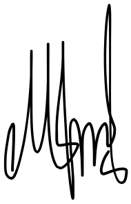

I Gede Nyoman Mindra Jaya

Ketua Program Studi S2 Statistika Terapan  
FMIPA Universitas Padjadjaran